# CO2 Emission by Vehicles

Team Scienzo - Luka Marković, Vildan Čuturić

## Uvod

Skup podataka CO2 Emission by Vehicles sadrži podatke o vozilima u Kanadi kao što su marka, model, vrsta karoserije, veličina motora, broj cilindara, tip menjača, tip goriva i potrošnja goriva u zavisnosti od vrste vožnje (gradska, autoput, kombinovana)

Takođe, sadrži atribut pod nazivom CO2 Emissions koji zapravo predstavlja emisiju ugljen dioksida automobila, i taj atribut ćemo probati da pretpostavimo.

Detaljnije informacije o podacima u nastavku.

### Učitavanje podataka

```r
library("knitr")
library("tidyverse")
```

```r
library(ggplot2)
```

Biblioteku **knitr** koristimo zbog funkcije `kable()` koja nam uređuje data frame.

```r
co2_emission = read_csv("CO2 Emissions_Canada.csv")
```

### Tumačenje podataka

| Naziv_atributa | Opis |
| --- | --- |
| Make | Marka automobila |
| Model | Model automobila |
| Vehicle Class | Karoserija |
| Engine Size(L) | Veličina Motora u litrima |
| Cylinders | Cilindar je komora u kojoj se sagoreva gorivo i proizvodi se snaga. Ova kolona je broj cilindara. |
| Transmission | Prenos: A - automatik, AM - automatizovani manuelni(kao manuelni samo bez kvačila), AS - automatik sa mogućnošću promene brzine, AV - (CVT) Continuously varibale transmission - bezosećajno menjanje br… |
| Fuel Type | Tip goriva: X - benzin, Z - premium benzin, D - dizel, E - etanol, N - prirodni gas. |
| Fuel Consumption City (L/100 km) | Potrošnja goriva u gradu (Litara na 100 kilometara). |
| Fuel Consumption Hwy (L/100 km) | Potrošnja goriva na otvorenom (Litara na 100 kilometara). |
| Fuel Consumption Comb (L/100 km) | Potrošnja goriva kombinacija (Litara na 100 kilometara) . |
| Fuel Consumption Comb (mpg) | Potrošnja goriva kombinacija (Miles Per Galon). |
| CO2 Emissions(g/km) | Emisija ugljen-dioksida (u gramima po kilometru) za kombinovanu vožnju po gradu i na autoputevima. |

## Obrada podataka

```r
library(corrplot)
```

Radi lakše obrade menjamo nazive kolona.

```r
custom_col_names <- c("Make", "Model", "VehicleClass", "EngineSize", "Cylinders", "Transmission", "FuelType", "FCCity", "FCHighway", "FCComb", "FCCombMPG", "CO2Emission")
colnames(co2_emission) <- custom_col_names

co2_emission <- co2_emission %>%
  mutate(FuelType = recode(FuelType,
                           D = "Diesel",
                           E = "Ethanol",
                           N = "Natural Gas",
                           X = "Gasoline",
                           Z = "PremiumGasoline"))
```

```r
str(co2_emission)
```

```
## tibble [7,385 × 12] (S3: tbl_df/tbl/data.frame)
##  $ Make        : chr [1:7385] "ACURA" "ACURA" "ACURA" "ACURA" ...
##  $ Model       : chr [1:7385] "ILX" "ILX" "ILX HYBRID" "MDX 4WD" ...
##  $ VehicleClass: chr [1:7385] "COMPACT" "COMPACT" "COMPACT" "SUV - SMALL" ...
##  $ EngineSize  : num [1:7385] 2 2.4 1.5 3.5 3.5 3.5 3.5 3.7 3.7 2.4 ...
##  $ Cylinders   : num [1:7385] 4 4 4 6 6 6 6 6 6 4 ...
##  $ Transmission: chr [1:7385] "AS5" "M6" "AV7" "AS6" ...
##  $ FuelType    : chr [1:7385] "PremiumGasoline" "PremiumGasoline" "PremiumGasoline" "PremiumGasoline" ...
##  $ FCCity      : num [1:7385] 9.9 11.2 6 12.7 12.1 11.9 11.8 12.8 13.4 10.6 ...
##  $ FCHighway   : num [1:7385] 6.7 7.7 5.8 9.1 8.7 7.7 8.1 9 9.5 7.5 ...
##  $ FCComb      : num [1:7385] 8.5 9.6 5.9 11.1 10.6 10 10.1 11.1 11.6 9.2 ...
##  $ FCCombMPG   : num [1:7385] 33 29 48 25 27 28 28 25 24 31 ...
##  $ CO2Emission : num [1:7385] 196 221 136 255 244 230 232 255 267 212 ...
```

Možemo zapaziti iz funkcije `str()` da su nam kolone Make, Model, Vehicle Class(karoserija), Transmission(Prenos) i Fuel Type(Tip goriva) kategorijske promenljive.

## Cišćenje null vrednosti

```r
naCounts = co2_emission %>%
  summarize(across(everything(), ~sum(is.na(.))))

na_counts_long <- pivot_longer(naCounts, cols = everything(), names_to = "Column", values_to = "NA_Count")

print(na_counts_long)
```

```
## # A tibble: 12 × 2
##    Column       NA_Count
##    <chr>           <int>
##  1 Make                0
##  2 Model               0
##  3 VehicleClass        0
##  4 EngineSize          0
##  5 Cylinders           0
##  6 Transmission        0
##  7 FuelType            0
##  8 FCCity              0
##  9 FCHighway           0
## 10 FCComb              0
## 11 FCCombMPG           0
## 12 CO2Emission         0
```

**Mozemo zaključiti da nemamo NULL vrednosti u dataset-u**

## Provera kolone Make

Možemo napraviti tabelu učestalosti kako bi proverili koliko ima određenih marki automobila

```r
co2_emission %>%
  group_by(Make) %>%
  summarize(Vehicles = n()) %>%
  arrange(desc(Vehicles))
```

```
## # A tibble: 42 × 2
##    Make          Vehicles
##    <chr>            <int>
##  1 FORD               628
##  2 CHEVROLET          588
##  3 BMW                527
##  4 MERCEDES-BENZ      419
##  5 PORSCHE            376
##  6 TOYOTA             330
##  7 GMC                328
##  8 AUDI               286
##  9 NISSAN             259
## 10 JEEP               251
## # ℹ 32 more rows
```

Nakon toga, radi vizuelizacija možemo to prikazati na bar plotu

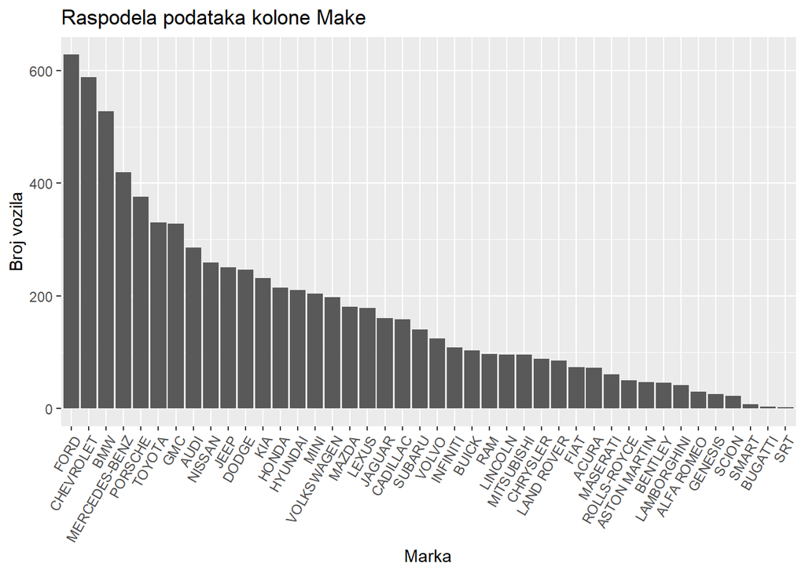

```r
ggplot(co2_emission, aes(x = reorder(Make, Make, function(x) -length(x)))) +
  geom_bar() +
  labs(title = "Raspodela podataka kolone Make", x = "Marka", y = "Broj vozila") +
  theme(axis.text.x = element_text(angle = 60, hjust = 1))
```

Možemo primetiti da u broju dominiraju Američke marke automobila, pošto je skup podataka prikupljen u Kanadi ovo nije čudno. Sa druge strane spektra dominiraju luksuznije marke automobila, što je očekivano (što je auto skuplji to će ih biti manje) i pored toga marka Smart se nalazi u malom broju (veoma je moguće da ovakav automobil nema praktičnu primenu u gradovima u Kanadi koji su orjentisani prema automobilima tj. koji su planski gradjeni i gde nije problem naći parking mesto, a pored toga na tržištu u kojem dominiraju modeli većih dimenzija se smatra da ovako mali auto nije bezbedan). Ove pretpostavke na osnovu domenskog znanja možemo potkrepiti ili opovrgnuti u daljoj analizi podataka tako što ćemo proveriti broj SUV modela i generalno automobila većih dimenzija naspram broja manjih i ekonomičnijih modela. **Ovo uzimamo u razmatranje zato što bi ovakav trend mogao loše da utiče na primenljivost bilo kakve pretpostavke na osnovu ovog dataseta za tržišta koja se nalaze van severne Amerike.** Ako podaci u datasetu naginju ka većem broju automobila koji su generalno veći (veća težina - veće kubikaže - više zagađenja), zaključci izvedeni na osnovu njega ne moraju nužno da budu primenljivi za neko šire shvatanje zagađenja na nekoj drugoj lokaciji kao što je npr. Evropsko tržište, a model će verovatno lošije predvidjati za takve skupove podataka.

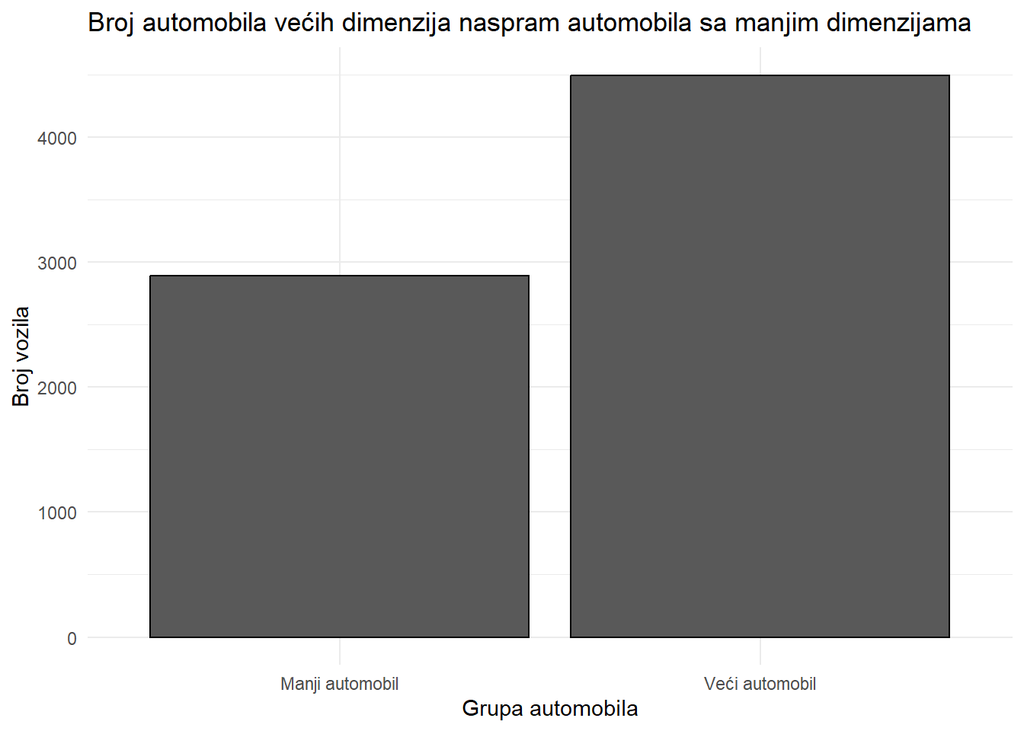

```r
vehicleClassGroup <- data.frame(
  Make = co2_emission$Make,
  VehicleClass = co2_emission$VehicleClass
)

classify_vehicle <- function(vehicle_class) {
  bigger_classes <- c("SUV - SMALL", "MID-SIZE", "FULL-SIZE", "SUV - STANDARD", "VAN - CARGO", "PICKUP TRUCK - STANDARD", "MINIVAN", "SPECIAL PURPOSE VEHICLE", "STATION WAGON - MID-SIZE")

  if (vehicle_class %in% bigger_classes) {
    return("Veći automobil")
  } else {
    return("Manji automobil")
  }
}

vehicleClassGroup$VehicleGroup <- sapply(vehicleClassGroup$VehicleClass, classify_vehicle)

ggplot(vehicleClassGroup, aes(x = VehicleGroup)) +
  geom_bar(color = "black") +
  xlab("Grupa automobila") +
  ylab("Broj vozila") +
  ggtitle("Broj automobila većih dimenzija naspram automobila sa manjim dimenzijama") +
  theme_minimal()
```

Sada bi mogli da proverimo koliko koja marka ima kakvih automobila, uzimajući u obzir i karoseriju automobila.

```r
library(viridis)
```

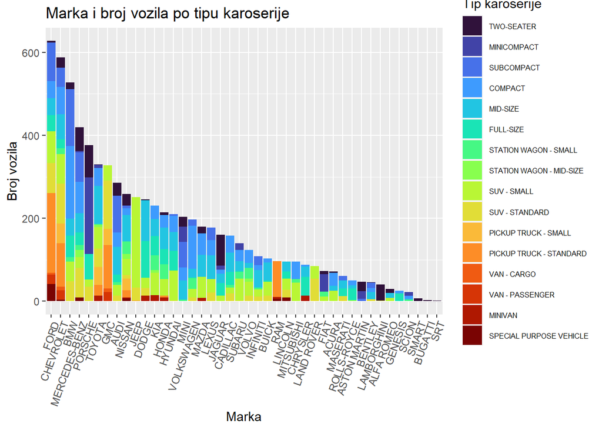

```r
vehicleClassOrdered = c(
  "TWO-SEATER",
  "MINICOMPACT",
  "SUBCOMPACT",
  "COMPACT",
  "MID-SIZE",
  "FULL-SIZE",
  "STATION WAGON - SMALL",
  "STATION WAGON - MID-SIZE",
  "SUV - SMALL",
  "SUV - STANDARD",
  "PICKUP TRUCK - SMALL",
  "PICKUP TRUCK - STANDARD",
  "VAN - CARGO",
  "VAN - PASSENGER",
  "MINIVAN",
  "SPECIAL PURPOSE VEHICLE"
)

ggplot(vehicleClassGroup, aes(x = reorder(Make, Make, function(x) -length(x)))) +
  geom_bar(aes(fill = factor(VehicleClass, levels = vehicleClassOrdered ))) +
  scale_fill_viridis_d(option = "turbo")+
  labs(title = "Marka i broj vozila po tipu karoserije", x = "Marka", y = "Broj vozila") +
  theme(axis.text.x = element_text(angle = 70, hjust = 1))+
  guides(fill = guide_legend(
    title = "Tip karoserije",
    title.position = "top",
    label.theme = element_text(size = 6)
  ))
```

Ovde možemo primetiti detaljnije da su marke iz SAD (Ford, GMC, Buick, RAM, …) okarakterisane vozilima većih karoserija (boje u opsegu crvene su vezane za veće karoserije) dok su evropske marke (Mini, Volkswagen, Porsche, …) okarakterisane vozilima manjih karoserija (boje u opsegu plave označavaju manje karoserije). Na ovakvoj raspodeli, za azijske marke (Honda, KIA, Nissan,…) važi da spadaju negde između ove dve krajnosti, tj. da su u datasetu zastupljene sa vozilima koja imaju “srednju” veličinu karoserije, ali ipak ovakvo stanje situacije ide u korist pretpostavci navedenoj iznad.

Jedina kategorija karoserije koju je teško kategorizovati u ovom slučaju su dvosedi (two-seater) tj. vozila koja su fokusirana na brzu, sportsku vožnju. Problem u ovoj vrsti kategorije leži u tome što su te karoserije relativno male, ali motori koji se koriste u njima su jači i većih zapremina.

Za veću preglednost, možemo iskoristiti već napravljenu podelu na manje i veće karoserije i ubaciti to na grafik.

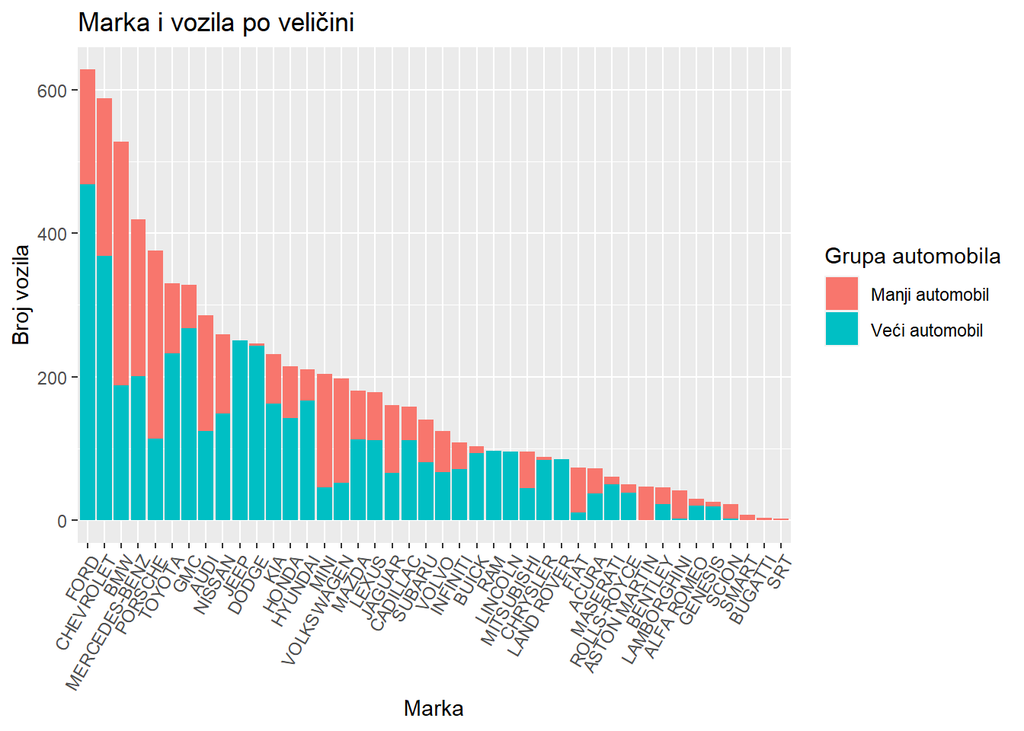

```r
  ggplot(vehicleClassGroup, aes(x = reorder(Make, Make, function(x) -length(x)))) +
  geom_bar(aes(fill = VehicleGroup)) +
  labs(title = "Marka i vozila po veličini", x = "Marka", y = "Broj vozila", fill = "Grupa automobila") +
  theme(axis.text.x = element_text(angle = 60, hjust = 1))
```

Ovde već možemo malo lakše primetiti trendove koje smo naveli za gornji grafik, i ako gubimo malo na preciznosti ovakvom generalizacijom.

Možemo da izvučemo prosek emisije CO2 prema marki vozila, kakva je povezanost ove dve kolone?

```r
emByMake <- co2_emission %>%
  group_by(Make) %>%
  summarize(AvgCO2 = mean(CO2Emission))

emByMake_df <- as.data.frame(emByMake)

colnames(emByMake_df) <- c("Make", "Average CO2 Emission(g/km)")

print(head(emByMake_df, 15), right=F)
```

```
##    Make         Average CO2 Emission(g/km)
## 1  ACURA        223.6528
## 2  ALFA ROMEO   224.9000
## 3  ASTON MARTIN 339.6170
## 4  AUDI         250.8462
## 5  BENTLEY      362.9348
## 6  BMW          254.0076
## 7  BUGATTI      522.0000
## 8  BUICK        233.0583
## 9  CADILLAC     265.8544
## 10 CHEVROLET    264.3469
## 11 CHRYSLER     246.1705
## 12 DODGE        276.3618
## 13 FIAT         192.2466
## 14 FORD         260.9889
## 15 GENESIS      284.8400
```

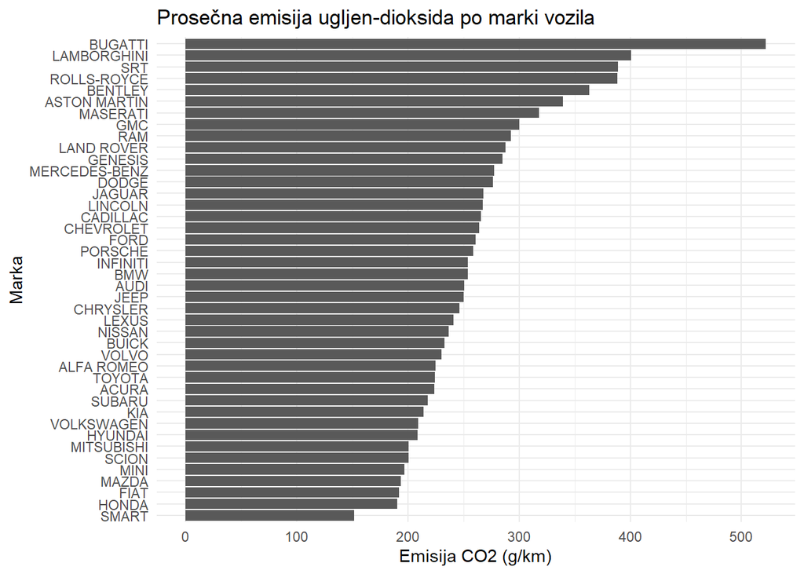

```r
emByMake$Make <- factor(emByMake$Make, levels = emByMake$Make[order(emByMake$AvgCO2)])

ggplot(emByMake, aes(x = Make, y = AvgCO2)) +
  geom_bar(stat = "identity", position = "dodge") +
  xlab("Marka") +
  ylab("Emisija CO2 (g/km)") +
  ggtitle("Prosečna emisija ugljen-dioksida po marki vozila") +
  theme_minimal() +
  coord_flip()
```

Na vrhu po zagađenju možemo naći skupocene marke, sa jedne strane to nije čudno jer se u njima u najvećem slučaju nalaze motori većih zapremina, ali sa druge strane ne mora da znači da je ovo reprezentativno ponašanje pošto tih marki nemamo puno u datasetu. Zanimljivost koju ovde možemo primetiti koja ide u korist onome što smo naveli gore je da su najmanji zagađivači ili evropske ili japanske marke automobila (prvi najmanji zagađivač iz SAD je marka Buick), što ide u korist onome što smo naveli gore.

## Provera kolone Model

```r
n_distinct(co2_emission$Model)
```

```
## [1] 2048
```

Pošto ovde imamo 2048 različitih modela automobila, bilo bi nepraktično da pokušavamo da dođemo do nekog zaključka na na isti način kojim smo to uradili za marke, ali i pored toga na osnovu domenskog znanja možemo da znamo da emisije CO2 se mogu razlikovati i kod istog modela u zavisnosti od toga koji je motor korišcen, pošto uvek postoji vise opcija. Na osnovu toga, možemo kasnije ukombinovati ovu kategorijsku promenljivu u neko predviđanje sa kolonom koja označava broj cilindara i transmisijom kako bi možda dobili bolje predviđanje na osnovu snage motora, što je u ovom slučaju glavno.

Ne vidimo način da ukrupnimo nekako ove podatke zarad vizuelizacije, a da se to ne svede na pregledanje ovih vozila po proizvođaču.

## Provera kolone Vehicle Class

Za početak, možemo proveriti koliko jedinstvenih vrednosti imamo u navedenoj koloni.

```r
n_distinct(co2_emission$VehicleClass)
```

```
## [1] 16
```

Koje su to vrednosti i koliko ih ima.

```r
co2_emission$VehicleClass = factor(co2_emission$VehicleClass)

vehicleClassCounts <- co2_emission %>%
  count(VehicleClass, name = "Vehicles") %>%
  arrange(desc(Vehicles))

vehicleClassCounts
```

```
## # A tibble: 16 × 2
##    VehicleClass             Vehicles
##    <fct>                       <int>
##  1 SUV - SMALL                  1217
##  2 MID-SIZE                     1133
##  3 COMPACT                      1022
##  4 SUV - STANDARD                735
##  5 FULL-SIZE                     639
##  6 SUBCOMPACT                    606
##  7 PICKUP TRUCK - STANDARD       538
##  8 TWO-SEATER                    460
##  9 MINICOMPACT                   326
## 10 STATION WAGON - SMALL         252
## 11 PICKUP TRUCK - SMALL          159
## 12 MINIVAN                        80
## 13 SPECIAL PURPOSE VEHICLE        77
## 14 VAN - PASSENGER                66
## 15 STATION WAGON - MID-SIZE       53
## 16 VAN - CARGO                    22
```

Distribucija podataka.

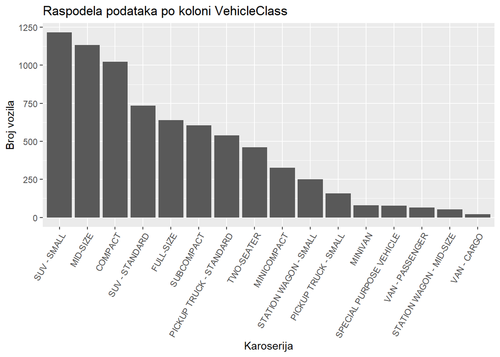

```r
ggplot(co2_emission, aes(x = reorder(VehicleClass, VehicleClass, function(x) -length(x)))) +
  geom_bar() +
  labs(title = "Raspodela podataka po koloni VehicleClass", x = "Karoserija", y = "Broj vozila") +
  theme(axis.text.x = element_text(angle = 60, hjust = 1))
```

Možemo da uradimo isto kao i za marke vozila, da proverimo prosečnu emisiju za karoseriju. Ovde već imamo malo *pravednije merenje*, jer u primeru marki smo imali npr. marku BUGGATI koja proizvodi samo brze sportske automobile sa jakim motorima, a naravno jači motor pravi više zagađenja.

```r
emByVehicleClass = co2_emission %>%
  group_by(VehicleClass) %>%
  summarize(AvgCO2 = mean(CO2Emission)) %>%
  arrange(desc(AvgCO2))

emByVehicleClass_df <- as.data.frame(emByVehicleClass)

colnames(emByVehicleClass_df) <- c("Vehicle Class", "Average CO2 Emission(g/km)")

print(head(emByVehicleClass_df, 15), right=F)
```

```
##    Vehicle Class            Average CO2 Emission(g/km)
## 1  VAN - PASSENGER          397.2121
## 2  VAN - CARGO              361.5000
## 3  SUV - STANDARD           304.8367
## 4  PICKUP TRUCK - STANDARD  301.5130
## 5  PICKUP TRUCK - SMALL     278.9686
## 6  TWO-SEATER               277.4543
## 7  FULL-SIZE                263.3161
## 8  MINIVAN                  262.3125
## 9  SUBCOMPACT               246.4488
## 10 STATION WAGON - MID-SIZE 238.6981
## 11 SPECIAL PURPOSE VEHICLE  237.5974
## 12 MINICOMPACT              236.6074
## 13 SUV - SMALL              236.2925
## 14 MID-SIZE                 222.4554
## 15 COMPACT                  216.6791
```

Možemo uočiti da malo veću emisiju prave VAN vozila tačnije putnički kombiji, što je i logično. Možemo to prikazati i grafom.

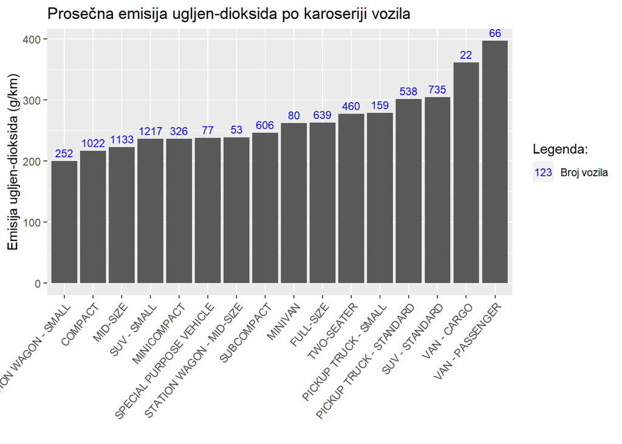

```r
emByVehicleClass$VehicleClass <- factor(emByVehicleClass$VehicleClass,levels=emByVehicleClass$VehicleClass[order(emByVehicleClass$AvgCO2)])

emByVehicleClass <- left_join(emByVehicleClass, vehicleClassCounts, by = "VehicleClass")

ggplot(emByVehicleClass, aes(x = VehicleClass, y = AvgCO2, label = Vehicles)) +
  geom_bar(stat = "identity") +
  geom_text(aes(color = "Broj vozila"), vjust = -0.5, size = 3) +
  xlab(" ") +
  ylab("Emisija ugljen-dioksida (g/km)") +
  ggtitle("Prosečna emisija ugljen-dioksida po karoseriji vozila") +
  theme(axis.text.x = element_text(angle = 50, hjust = 1)) +
  scale_color_manual(values = "blue", guide = guide_legend())+
  guides(color = guide_legend(override.aes = list(label = "123"), title = "Legenda:"))
```

Na osnovu ovog grafa dolazimo do veoma čudnih zaključaka, npr. da u proseku subcompact koji je manji tip karoserije ima veće emisije ugljen dioksida nego compact, mid-size i ostale veće klase automobila.

Kako bi dalje razmatrali ovaj problem možemo se vratiti na primer tipa karoserije “Two-seater”, tj. vozila koja imaju male karoserije, ali motore većih zapremina. Na osnovu tog primera, možemo doći do zaključka da tip karoserije nije nužan pokazazatelj toga koliko će vozilo zagađivati, ne možemo npr. napraviti pretpostavku da automobili manjih karoserija zagađuju manje, jer se to očigledno kosi sa primerom navedenim gore, tj. vidimo da je bitniji pokazatelj zagađenja zapravo motor vozila, a ne tip karoserije sam po sebi.

Generalno, ovde je loše urađena raspodela na klase automobila u samom datasetu, nisu dati detalji na osnovu čega su automobili podeljeni na ove klase. Na osnovu Wikipedije (https://en.wikipedia.org/wiki/Vehicle_size_class), u Kanadi se automobili dele na 5 klasa, a ovde ih imamo 16, i pored toga se dele na osnovu unutrašnje zapremine vozila (ne motora) ili težine samog vozila, a ovde ne posedujemo ni jednu od te dve varijable.

U ovom datasetu nije navedeno na osnovu čega su automobili podeljeni u ove klase i to može napraviti problem za izvlačenje zaključaka iz ove kolone, a ne možemo ispraviti tu grešku jer nisu date zapremine automobila (unutrašnja zapremina vozila u litrima ili kubnim stopama), njihova težina ili bilo šta sto nam može pomoći da pravilno klasifikujemo ova vozila prema veličini već se moramo uzdati u postojeću raspodelu.

Na osnovu svega toga za sad ćemo zanemariti ovu kolonu i pokušati da izvučemo bolje zaključke na osnovu kubikaže motora automobila koja bi trebalo da nam da bolje informacije o tome kakve bi emisije CO2 mogli da očekujemo, ali možemo je svakako uključiti u kreiranje modela u kasnijem roku.

## Provera kolone Engine Size

Za početak možemo videti koliko imamo različitih veličina motora.

```r
n_distinct(co2_emission$EngineSize)
```

```
## [1] 51
```

Koji su to veličine i koliko ih je.

```r
co2_emission$EngineSize = factor(co2_emission$EngineSize)

co2_emission %>%
  count(EngineSize, name = "Vehicles") %>%
  arrange(desc(Vehicles))
```

```
## # A tibble: 51 × 2
##    EngineSize Vehicles
##    <fct>         <int>
##  1 2              1460
##  2 3               804
##  3 3.6             536
##  4 3.5             529
##  5 2.5             423
##  6 2.4             346
##  7 1.6             302
##  8 5.3             290
##  9 1.8             216
## 10 1.4             211
## # ℹ 41 more rows
```

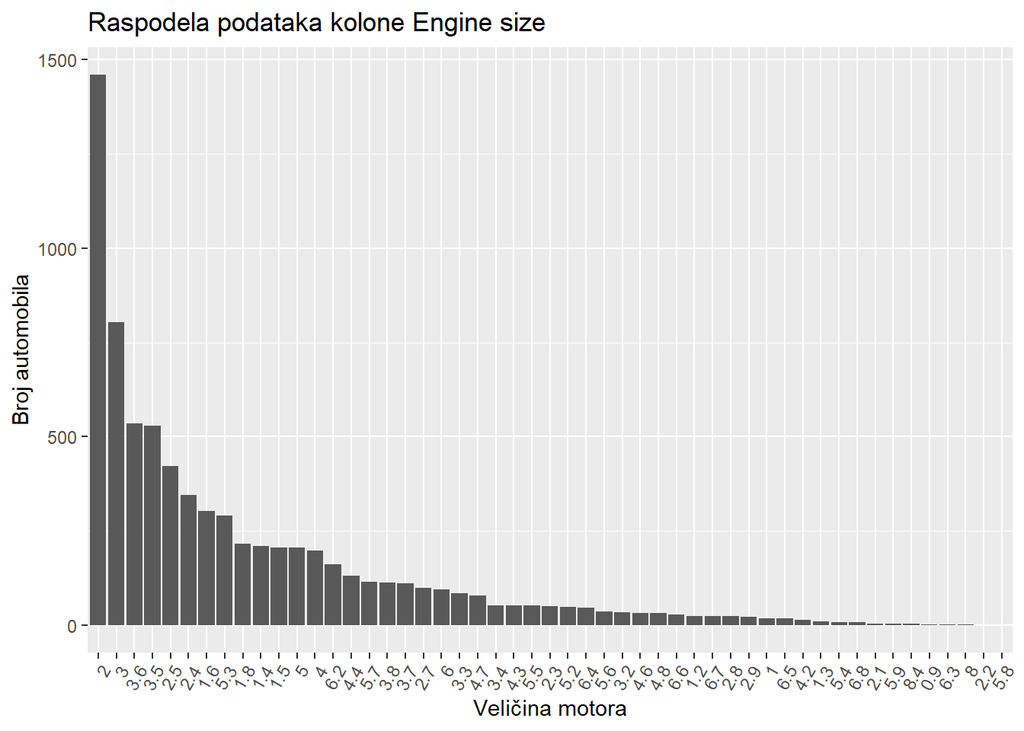

```r
enSizePlot <- ggplot(co2_emission, aes(x = reorder(EngineSize, EngineSize, function(x) -length(x)))) +
  geom_bar() +
  labs(title = "Raspodela podataka kolone Engine size", x = "Veličina motora", y = "Broj automobila") +
  theme(axis.text.x = element_text(angle = 60, hjust = 1))

enSizePlot
```

Pošto se najveći broj kubikaža nalazi na prvoj polovini plota ako ga gledamo po x osi, možemo uzumirati plot kako bi ga bolje pogledali

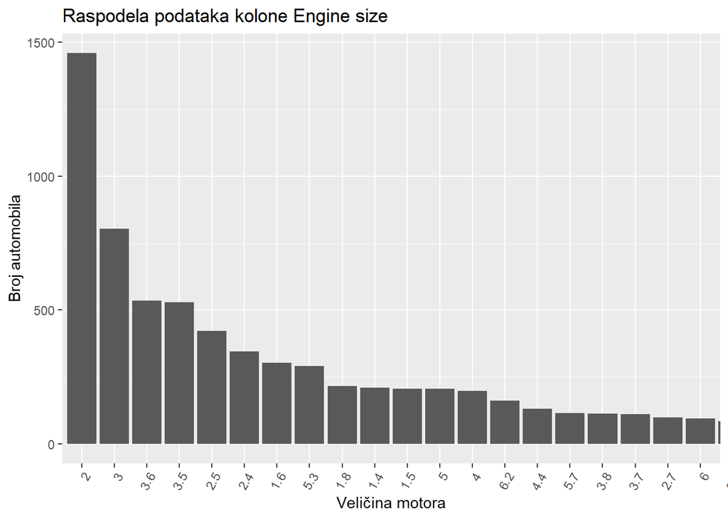

```r
enSizePlot + coord_cartesian(xlim = c(1, 20.0))
```

Dalje, kako bi dobili bolju sliku o tome kako su ovi motori raspodeljeni i koliko ima velikih, srednjih i malih motora, možemo podeliti sve ove kubikaže u te tri klase (npr. razlika izmedju 3.5 i 3.6 je minimalna, obe ove kubikaže bi bile u jednoj klasi) na sledeći način:

Mali motori - sve kubikaže do 2.0L

Srednji motori - od 2.0L do 4.0L

Veliki motori - od 4.0L i više

```r
cut = c(0, 2, 4, Inf)
co2_emission$EngineSize <- as.numeric(as.character(co2_emission$EngineSize))

engineClasses = cut(co2_emission$EngineSize, cut, labels = c("Mala", "Srednja", "Velika"))

engineClasses = data.frame(EngineClass = engineClasses)

engineClasses %>%
  count(EngineClass, name = "Vehicles") %>%
  arrange(desc(Vehicles))
```

```
##   EngineClass Vehicles
## 1     Srednja     3437
## 2        Mala     2453
## 3      Velika     1495
```

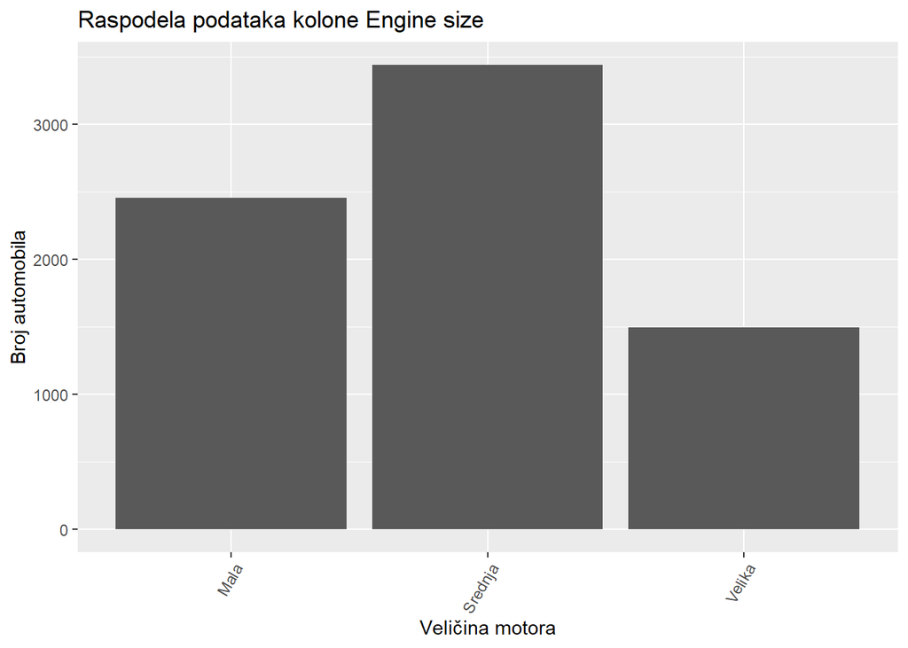

```r
ggplot(engineClasses, aes(x = EngineClass)) +
  geom_bar() +
  labs(title = "Raspodela podataka kolone Engine size", x = "Veličina motora", y = "Broj automobila") +
  theme(axis.text.x = element_text(angle = 60, hjust = 1))
```

Na ovom grafiku možemo veoma dobro primetiti da dominiraju motori srednjih zapremina, ali to uključuje sve kubikaže do 4L koja je i dalje sama po sebi poprilično velika, a i pored toga imamo još skoro 1500 motora kubikaža većih od 4L što nas dovodi do zaključka da u ovom datasetu imamo poprilično veći broj automobila koji bi mogli da se smatraju većim zagađivačima.

Dalje možemo kao i kod prethodnih primera proveriti prosečnu emisiju CO2 po veličini motora.

```r
emByEngineSize = co2_emission %>%
  group_by(EngineSize) %>%
  summarize(AvgCO2 = mean(CO2Emission)) %>%
  arrange(desc(AvgCO2))

emByEngineSize_df <- as.data.frame(emByEngineSize)

colnames(emByEngineSize_df) <- c("Engine Size", "Average CO2 Emission(g/km)")

print(head(emByEngineSize_df, 15), right=F)
```

```
##    Engine Size Average CO2 Emission(g/km)
## 1  8.0         522.0000
## 2  6.5         453.5000
## 3  6.8         432.3750
## 4  6.7         393.0800
## 5  6.0         384.9894
## 6  6.6         379.8621
## 7  8.4         378.4000
## 8  5.4         373.3750
## 9  5.9         360.2000
## 10 6.3         350.3333
## 11 5.2         350.0417
## 12 4.2         339.7857
## 13 4.8         339.1250
## 14 5.6         334.9444
## 15 5.5         332.9808
```

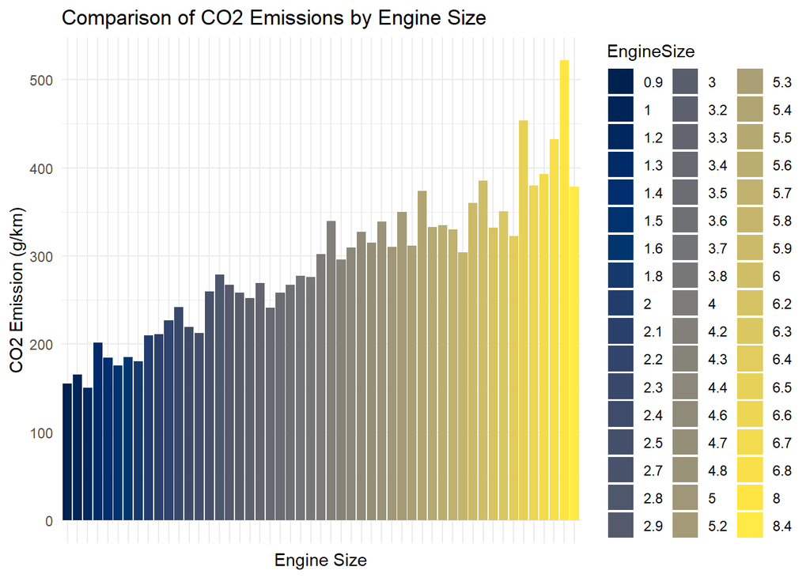

```r
data <- data.frame(
  EngineSize = as.character(emByEngineSize$EngineSize),
  CO2Emission = emByEngineSize$AvgCO2
)

ggplot(data, aes(x = EngineSize, y = CO2Emission, fill = EngineSize)) +
  geom_bar(stat = "identity", position = "dodge") +
  scale_fill_viridis(discrete = TRUE, option = "cividis") +
  xlab("Engine Size") +
  ylab("CO2 Emission (g/km)") +
  ggtitle("Comparison of CO2 Emissions by Engine Size") +
  theme_minimal() +
  theme(axis.text.x = element_blank())
```

Na osnovu plota možemo potvrditi ono što smo već znali, a to je da motori većih kubikaža više i zagađuju ali ono što takođe možemo primetiti je da taj trend ne važi uvek, imamo slučajeve gde veći motori zagađuju manje što može napraviti probelm pri korišćenju ove kolone u modelu jer će nam biti potrebna sigurno još neka koja mora da objasni ovaj fenomen kako bi dolazili do ispravnih zaključaka.

## Provera kolone Cylinders

Možemo proveriti koliko automobila ima koliko cilindara i ujedno prikazati i distribuciju podataka ove kolone.

```r
cylindersCount <- co2_emission %>%
  count(Cylinders, name = "Vehicles") %>%
  arrange(desc(Vehicles))

cylindersCount
```

```
## # A tibble: 8 × 2
##   Cylinders Vehicles
##       <dbl>    <int>
## 1         4     3220
## 2         6     2446
## 3         8     1402
## 4        12      151
## 5         3       95
## 6        10       42
## 7         5       26
## 8        16        3
```

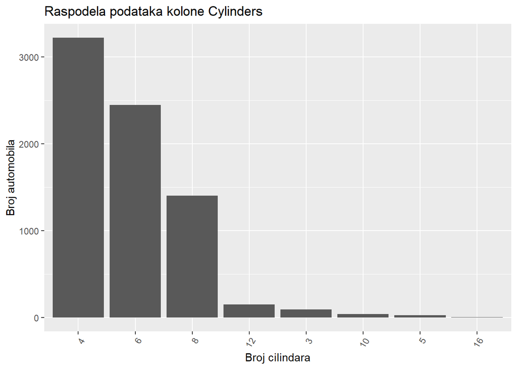

```r
cylindersPlot <- ggplot(co2_emission, aes(x = reorder(Cylinders, Cylinders, function(x) -length(x)))) +
  geom_bar() +
  labs(title = "Raspodela podataka kolone Cylinders", x = "Broj cilindara", y = "Broj automobila") +
  theme(axis.text.x = element_text(angle = 60, hjust = 1))

cylindersPlot
```

Možemo primetiti da dominiraju motori sa 4 cilindra koji bi u velikom broju slučajeva trebali da budu manji zagađivači ako ne posmatramo kubikažu motora, a ako gledamo zajedno motore sa 6 i 8 cilindara, ima ih u malo većem broju. Naspram toga imamo poprilično mali broj motora sa velikim brojem cilindara (10,12,16) i onih motora sa neparnim brojem cilindara koji su generalno retki u automobilizmu.

Sada možemo da proverimo prosečnu emisiju CO2 po broju cilindara.

```r
emByCylinders = co2_emission %>%
  group_by(Cylinders) %>%
  summarize(AvgCO2 = mean(CO2Emission)) %>%
  arrange(desc(AvgCO2))

emByCylinders_df <- as.data.frame(emByCylinders)

colnames(emByCylinders_df) <- c("Cylinders", "Average CO2 Emission(g/km)")

print(head(emByCylinders_df, 10), right=F)
```

```
##   Cylinders Average CO2 Emission(g/km)
## 1 16        522.0000
## 2 12        381.0331
## 3 10        361.3095
## 4  8        320.6191
## 5  6        263.4469
## 6  5        235.6923
## 7  4        204.8599
## 8  3        174.8947
```

Odmah možemo zaključiti da što veći broj cilindara na motoru automobila rezultira u većoj emisiji CO2. Možemo da to i prikažemo grafički.

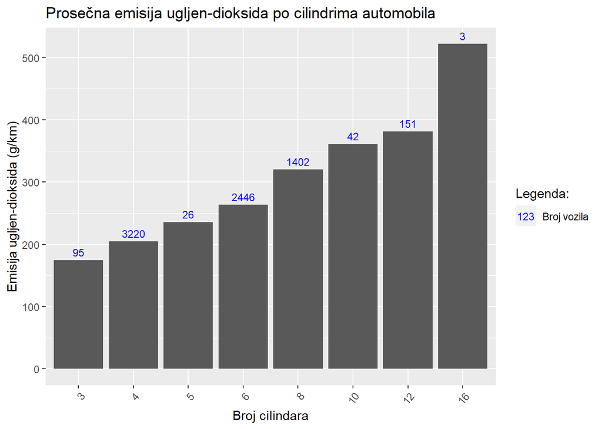

```r
data <- data.frame(
  Cylinders = emByCylinders$Cylinders,
  CO2Emission = emByCylinders$AvgCO2
)

data <- left_join(data, cylindersCount, by = "Cylinders")

data$Cylinders <- factor(as.character(emByCylinders$Cylinders), levels = as.character(emByCylinders$Cylinders)[order(emByCylinders$Cylinders)])


p <- ggplot(data, aes(x = Cylinders, y = CO2Emission, label = Vehicles)) +
  geom_bar(stat = "identity", position = "dodge") +
  geom_text(aes(color = "Broj vozila"), vjust = -0.5, size = 3) +
  xlab("Broj cilindara") +
  ylab("Emisija ugljen-dioksida (g/km)") +
  ggtitle("Prosečna emisija ugljen-dioksida po cilindrima automobila") +
  theme(axis.text.x = element_text(angle = 50, hjust = 1)) +
  scale_color_manual(values = "blue", guide = guide_legend())+
  guides(color = guide_legend(override.aes = list(label = "123"), title = "Legenda:"))

print(p)
```

## Provera kolone Transmission

```r
library(tidyr)
```

Biblioteku **tidyr** koristimo kako bi razdvojili određenje podatke, u našem slučaju npr. M6 bi označavao manuleni menjač sa 6 brzina, preglednije je da razdvojimo ovaj podatak i biće nam korisno za izradu grafa. Možemo proveriti kakve to sve prenose vozila imamo u Kanadi, koliko brzina i koliko vozila koristi koji prenos sa koliko brzina.

```r
transmission_vehicles <- co2_emission %>%
  count(Transmission, name = "Vehicles", sort = TRUE)

transmission_vehicles
```

```
## # A tibble: 27 × 2
##    Transmission Vehicles
##    <chr>           <int>
##  1 AS6              1324
##  2 AS8              1211
##  3 M6                901
##  4 A6                789
##  5 A8                490
##  6 AM7               445
##  7 A9                339
##  8 AS7               319
##  9 AV                295
## 10 M5                193
## # ℹ 17 more rows
```

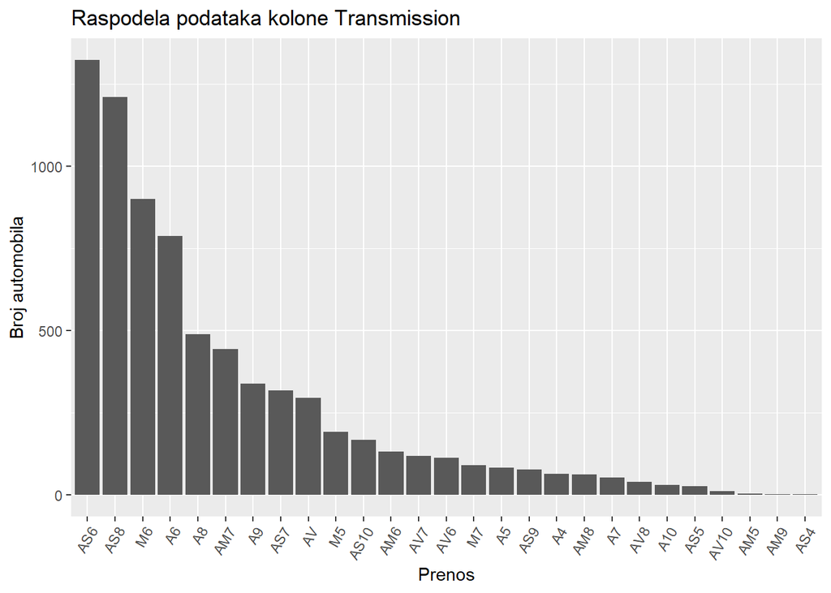

```r
transmissionPlot <- ggplot(co2_emission, aes(x = reorder(Transmission, Transmission, function(x) -length(x)))) +
  geom_bar() +
  labs(title = "Raspodela podataka kolone Transmission", x = "Prenos", y = "Broj automobila") +
  theme(axis.text.x = element_text(angle = 60, hjust = 1))

transmissionPlot
```

Možemo primetiti da po ovom datasetu u Kanadi se najviše voze vozila sa AS6 prenosom tačnije, automatik sa mogućnošću ručne promene brzine i 6 brzina. Generalno, ako se oslanjamo na domensko znanje, mogli smo da pretpostavimo da će automatici dominirati u ovom datasetu pošto su oni generalno popularni u severnoj Americi.

Za razmatranje ove kolone možemo se osloniti na domensko znanje o tipovima menjača, tj. testirati sledeću pretpostavku:

Stariji automatski menjači nisi imali mogućnosti pravovremenog i odgovarajućeg odabira brzine u pojedinim slučajevima, npr. ostavljali bi automobil u neodgovarajućem stepenu prenosa za uslove vožnje što bi rezultiralo u većoj potrošnji goriva i većem zagađenju.

Suprotno od toga, u idelanom slučaju, vozač automobila sa manuelnim menjačem je mogao sam prilagoditi stepen prenosa kako bi motor radio na što manjim obrtajima i manje trošio.

Na osnovu toga, postoji i mit o tome da su automatici veći potrošači goriva od manuelnih menjača (pod uslovom da je vozač obazriv). Ali ipak, korišćenjem modernih tehnologija i proizvodnjom automatskih menjača koji su mnogo precizniji i brži pri menjanju brzina od čoveka trebalo bi da je ovaj problem otklonjen, i to ćemo proveriti.

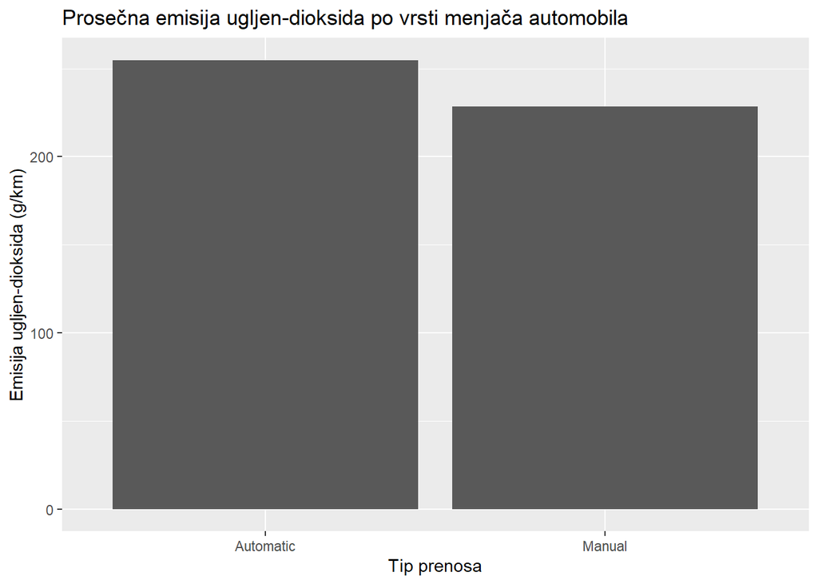

```r
tranType <- co2_emission %>%
  mutate(Transmission = case_when(
    grepl("A", Transmission) ~ "Automatic",
    grepl("M", Transmission) ~ "Manual",
    TRUE ~ "Other"
)) %>%
  group_by(Transmission) %>%
  summarize(AvgCO2 = mean(CO2Emission, na.rm = TRUE))


tranType$Transmission = as.factor(tranType$Transmission)

ggplot(tranType, aes(x = Transmission, y = AvgCO2)) +
  geom_bar(stat = "identity", position = "dodge") +
  xlab("Tip prenosa") +
  ylab("Emisija ugljen-dioksida (g/km)") +
  ggtitle("Prosečna emisija ugljen-dioksida po vrsti menjača automobila")
```

Izgleda da mit i dalje važi, tj. da ovo nije mit, automatici imaju veću emisiju izduvnih gasova od manuelnih menjača, ali takođe ta promenjliva će u stvarnom životu zavisiti dosta od stila vožnje samog vozača ( neko ko se trudi da konstantno vozi u što većem stepenu prenosa na što manjim obrtajima će trošiti manje goriva od nekog ko vozi veoma agresivno i menja brzine tek kada motor dostigne veći broj obrtaja) i same sredine u kojoj se vrši vožnja ( na autoputu gde se konstantno vozi u visokom stepenu prenosa potrošnja će biti generalno manja nego u gradskoj vožnji gde se stepen prenosa često menja).

Možemo se za sad vratiti nazad na sitnije podele po tipu prenosa i proveriti kako su one povezane sa emisijom CO2.

```r
emByGears = co2_emission %>%
  group_by(Transmission)

emByGears$Transmission = as.numeric(gsub("[^0-9]", "", emByGears$Transmission))

emByGears <- emByGears %>%
  summarise(AvgCO2 = mean(CO2Emission))%>%
  arrange(desc(AvgCO2))

emByGears_df <- as.data.frame(emByGears)

colnames(emByGears_df) <- c("Transmission", "Average CO2 Emission(g/km)")

print(head(emByGears_df, 10), right=F)
```

```
##   Transmission Average CO2 Emission(g/km)
## 1  4           290.9701
## 2 10           281.7857
## 3  8           267.5078
## 4  7           263.6647
## 5  9           247.6014
## 6  6           243.5716
## 7  5           229.7622
## 8 NA           173.7186
```

Kako bi lakše dolazili do zaključaka ovo možemo postaviti na plot

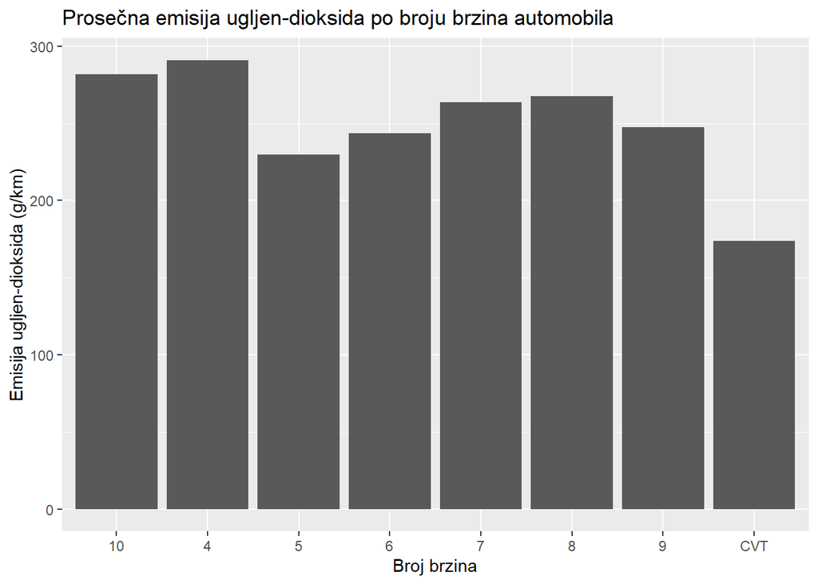

```r
emByGears$Transmission <- replace(emByGears$Transmission, is.na(emByGears$Transmission), "CVT")

emByGears$Transmission = as.factor(emByGears$Transmission)

ggplot(emByGears, aes(x = Transmission, y = AvgCO2)) +
  geom_bar(stat = "identity", position = "dodge") +
  xlab("Broj brzina") +
  ylab("Emisija ugljen-dioksida (g/km)") +
  ggtitle("Prosečna emisija ugljen-dioksida po broju brzina automobila")
```

Ovde je već malo teže doći do konkretnih zaključaka na osnovu broja brzina, na osnovu plota se vidi nešto sto je na prvi pogled čudno, vozila sa malim brojem brzina zagađuju dosta (4 brzine) a pored toga i vozila sa velikim brojem brzina takođe dosta zagađuju.

Sada možemo koristiti domensko znanje kako bi objasnili ovaj fenomen:

Znajući da veći broj brzina omogućava bolju kontrolu broja obrtaja u različitim uslovima vožnje bi smo mogli da dođemo do zaključka da su vozila sa većim brojem brzina manji zagađivači, što očigledno nije tačno jer su vozila sa 10 brzina približno slična po zagađenju kao vozila sa 4 brzine. Ali u ovom razmatranju izostavljamo jednu činjenicu, a to je da su vozila koja imaju ovoliko veliki broj brzina u najvećem broju slučajeva šleperi sa velikim motorima koji će naravno biti veći zagađivači ili automatski menjači za koje smo već videli da zagađuju više.

Sada kada to znamo možemo ove podatke dovesti u kontekst:

-Najveći zagađivači su menjači sa 4 brzine - mali broj brzina sprečava prilagođavanje različitim uslovima vožnje, tj. forsira vozača da vozi na većim obrtajima (vozimo prebrzo za manji stepen prenosa ali ne možemo da se prebacimo u veći zbog uslova u saobraćaju i nemogućnosti da ubrzamo nakon promene stepena prenosa, samim tim trošimo i zagađujemo više - ovo je ostavljeno ovde i ako u našem datasetu ova činjenica ne važi jer nemamo manuelne menjače sa 4 brzine, kao što ćemo videti u daljem pregledu podataka)

-Zagađenje opada kada imamo 5 brzina, veći broj brzina i duži prenosni odnosi dozvoljavaju bolje prilagođavanje uslovima na putu.

-U slučaju 6 brzina zagađenje ponovo raste, ali to je zato što taj broj brzina u velikom broju slučajevima imaju jači i veći motori

-7 i 8 brzina, ponovo imamo rast zagađenja

-9 brzina, ponovo imamo pad (zašto?)

-10 brzina, ponovo rast (automatici i kamioni)

-CVT - continously variable transsmission - omogućavaju veoma efikasnu raspodelu snage motora u zavisnosti od uslova i samim tim rezultiraju u manjoj potrošnji tj. manjem zagađenju u našem slučaju

Sada ove dve vrednosti za menjače možemo pogledati zajedno, kako broj brzina i tip transmisije utiču na potrošnju, tj. zagađenje?

```r
emByTransmission = co2_emission %>%
  group_by(Transmission) %>%
  summarize(AvgCO2 = mean(CO2Emission))

emByTransmission <- separate(emByTransmission, col = Transmission, into = c("Type", "Gears"), sep = "(?<=\\D)(?=\\d)", remove = TRUE)
```

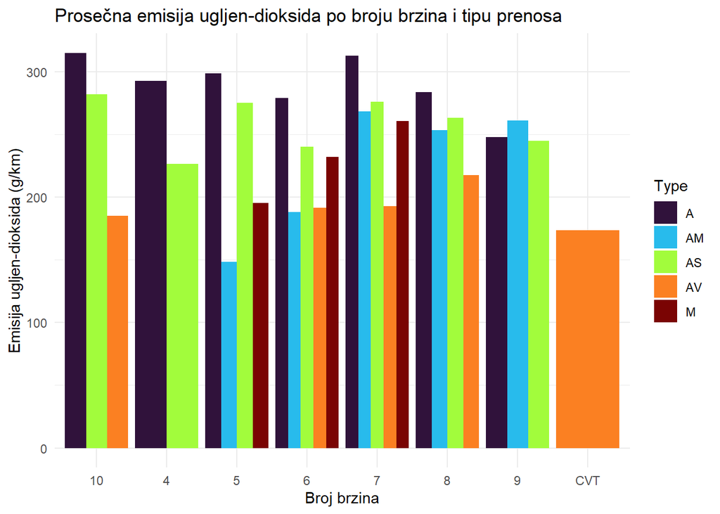

```r
emByTransmission$Gears <- replace(emByTransmission$Gears, is.na(emByTransmission$Gears), "CVT")

sorted_emByTransmission <- emByTransmission %>%
  arrange(desc(AvgCO2))

ggplot(emByTransmission, aes(x = Gears, y = AvgCO2, fill = Type)) +
  geom_bar(stat = "identity", position = "dodge") +
  scale_fill_viridis(discrete = TRUE, option = "turbo") +
  xlab("Broj brzina") +
  ylab("Emisija ugljen-dioksida (g/km)") +
  ggtitle("Prosečna emisija ugljen-dioksida po broju brzina i tipu prenosa") +
  theme_minimal()
```

Ovde još bolje primećujemo trendove koje smo razdvojeno objašnjavali u gornjim primerima:

*4-brzinci takođe ne postoje u manuelnim opcijama, u velikom broju slučajeva ovako mali broj stepena prenosa će imati stariji tipovi automatskih menjača a i odatle dolazi veća količina zagađenja iz razloga koje smo već naveli.

*5,6,7 - primećujemo da manuelni menjači manje zagađuju od automatika u pojedinim slučajevima, ali ovde već na scenu stupaju automatici sa većim brojem stepena prenosa koji su moderniji (“The first six-speed automatic was the ZF 6HP26 transmission, which debuted in the 2002 BMW 7 Series (E65)” - izvor: https://en.wikipedia.org/wiki/Automatic_transmission) i samim tim automobili koji ih koriste manje zagađuju.

Generalno, tip transmisije je dobar indikator toga koliko će auto zagađivati, ali preovlađivanje automatika može rezultirati u tome da zaključci na osnovu ovog skupa podataka budu lošiji ako se primene direktno na podatke sa naših prostora gde se u najvećem broju slučajeva voze automobili sa manuelnim transmisijama.

## Provera kolone Fuel Type

Možemo proveriti raspodelu automobila po tipovima goriva.

```r
fuelTypeCount <- co2_emission %>%
  count(FuelType, name = "Vehicles")

fuelTypeCount
```

```
## # A tibble: 5 × 2
##   FuelType        Vehicles
##   <chr>              <int>
## 1 Diesel               175
## 2 Ethanol              370
## 3 Gasoline            3637
## 4 Natural Gas            1
## 5 PremiumGasoline     3202
```

Pošto možemo primetiti da imamo samo jedno vozilo u datasetu koje koristi prirodni gas možemo ga ukloniti (1 naspram 7000)

```r
co2_emission<- co2_emission[co2_emission$FuelType != "Natural Gas", ]
```

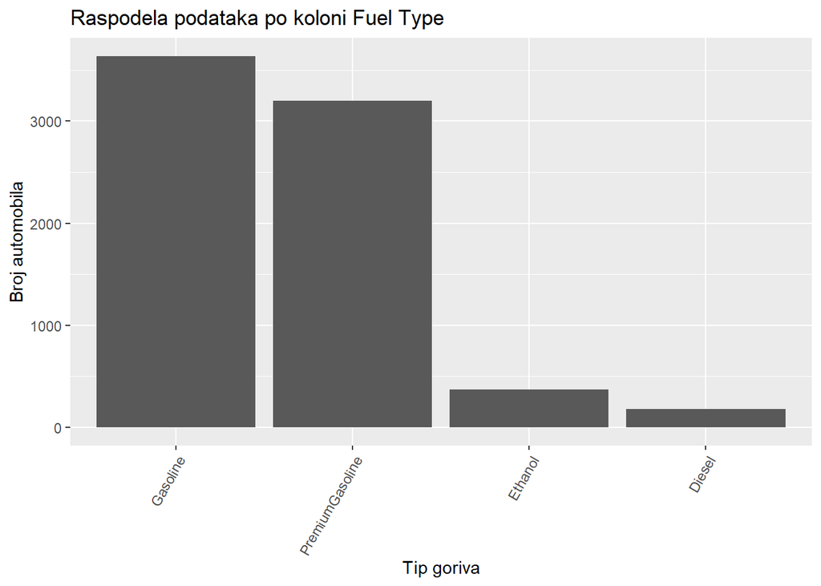

```r
fuelTypeCountPlot <- ggplot(co2_emission, aes(x = reorder(FuelType, FuelType, function(x) -length(x)))) +
  geom_bar() +
  labs(title = "Raspodela podataka po koloni Fuel Type", x = "Tip goriva", y = "Broj automobila") +
  theme(axis.text.x = element_text(angle = 60, hjust = 1))

fuelTypeCountPlot
```

Vidimo da se u Kanadi uglavnom voze benzinci, razlika je samo da li je gorivo malo kvalitetnije ili ne. Sada možemo proveriti prosečnu emisiju CO2 po tipu goriva.

```r
emByFuelType = co2_emission %>%
  group_by(FuelType) %>%
  summarize(AvgCO2 = mean(CO2Emission))

emByFuelType_df <- as.data.frame(emByFuelType)

colnames(emByFuelType_df) <- c("Fuel Type", "Average CO2 Emission(g/km)")

print(head(emByFuelType_df, 15), right=F)
```

```
##   Fuel Type       Average CO2 Emission(g/km)
## 1 Diesel          237.5486
## 2 Ethanol         275.0919
## 3 Gasoline        235.1193
## 4 PremiumGasoline 266.0434
```

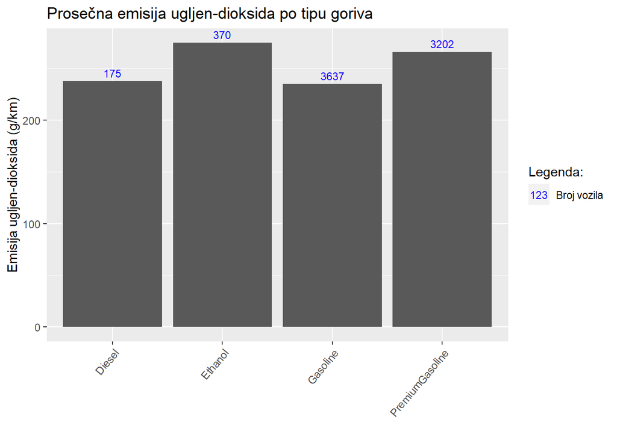

```r
data <- data.frame(
  FuelType = emByFuelType$FuelType,
  CO2Emission = emByFuelType$AvgCO2
)

data <- left_join(data, fuelTypeCount, by = "FuelType")

ggplot(data, aes(x = FuelType, y = CO2Emission, label = Vehicles)) +
  geom_bar(stat = "identity", position = "dodge") +
  geom_text(aes(color = "Broj vozila"), vjust = -0.5, size = 3) +
  xlab(" ") +
  ylab("Emisija ugljen-dioksida (g/km)") +
  ggtitle("Prosečna emisija ugljen-dioksida po tipu goriva") +
  theme(axis.text.x = element_text(angle = 50, hjust = 1)) +
  scale_color_manual(values = "blue", guide = guide_legend())+
  guides(color = guide_legend(override.aes = list(label = "123"), title = "Legenda:"))
```

Na osnovu ovakvog plota teško da možemo da zaključimo nešto korisno, veoma je čudno da u proseku etanol proizvodi više ugljen dioksida od dizela ili regularnog benzina, posebno ako se misli na čist etanol kao gorivo jer se etanol dodaje kao aditiv regularnom benzinu i čak premium benzinu u količini do 10%. Možemo da proverimo kakva to vozila koriste čist etanol. Možemo da proverimo kubikaže takvih vozila i da pretpostavimo da li bi trebalo da imaju ovako veliko zagađenje.

```r
ethanolVehicles<- subset(co2_emission, FuelType == "Ethanol")

ethanolVehicles %>%
  count(ethanolVehicles$EngineSize, name = "Vehicles") %>%
  arrange(desc(Vehicles))
```

```
## # A tibble: 15 × 2
##    `ethanolVehicles$EngineSize` Vehicles
##                           <dbl>    <int>
##  1                          5.3       96
##  2                          3.6       87
##  3                          5         43
##  4                          3.5       33
##  5                          2         22
##  6                          2.4       22
##  7                          4.3       20
##  8                          2.5       10
##  9                          3.3       10
## 10                          6          8
## 11                          3.7        7
## 12                          5.4        4
## 13                          6.2        4
## 14                          3          2
## 15                          4.6        2
```

Na prvi pogled deluje da etanol najviše koriste vozila sa većim kubikažama tako da nije čudno da u proseku zagađuju više, posebno zato što imamo samo 370 ovakvih vozila naspram skoro 6900 vozila koja idu na benzin.

Deluje možda da ova kolona i nije dobar izbor za predviđanje emisije CO2 ali ćemo je svakako isprobati u kasnijem radu.

## Provera kolona Fuel Consumption

Za početak vidimo da imamo dve jako slične kolone, tačnije, Fuel Consumption Comb(L/100km) i Consumption Comb(MPG), one bi trebale da pretstavljaju istu stvar, tačnije potrošnju goriva na otvorenom i u gradu, a razlika je samo u rasporedu promenljivih. Fuel Consumption Comb označava koliko litara trošimo da bi prešli 100km, a Consumption Comb MPG nam govori o tome koliko milja možemo da pređemo trošeći jedan galon goriva. Pored toga što su ove dve veličine obrnutno srazmerne, takođe imamo razliku u mernim jedinicama tj. Fuel Consumption Comb koristi metričke jedinice dok Consumption Comb koristi imperijalne jedinice mere. Na osnovu ovoga možemo se osloniti na jednu od ove dve kolone pri pravljenju modela jer u načelu označavaju istu stvar.

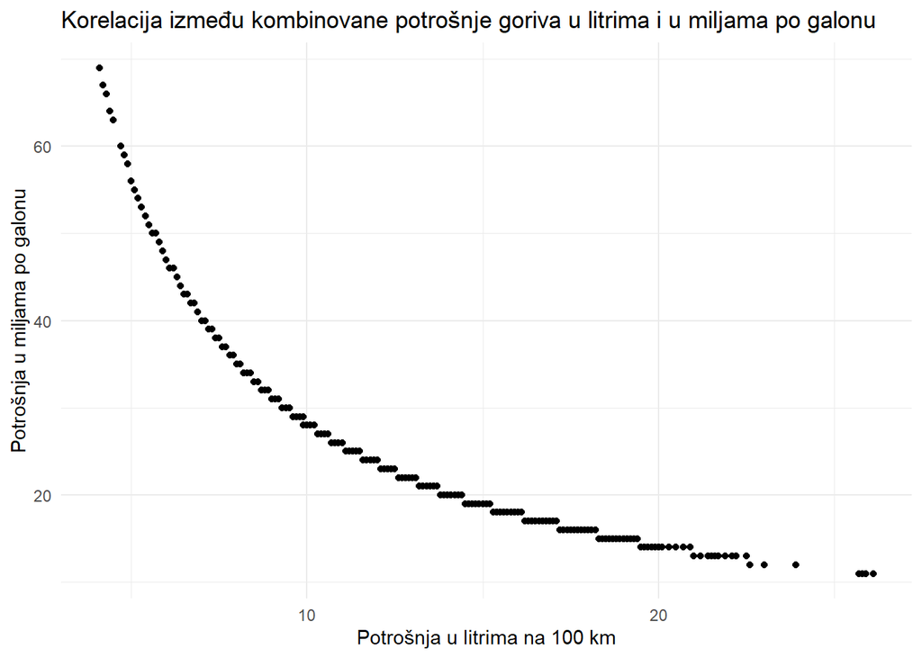

```r
ggplot(co2_emission, aes(x = FCComb, y = FCCombMPG)) +
  geom_point() +
  labs(title = "Korelacija između kombinovane potrošnje goriva u litrima i u miljama po galonu", x = "Potrošnja u litrima na 100 km", y = "Potrošnja u miljama po galonu") +
  theme_minimal()
```

Sa scatterplota možemo videti da imamo jaku, nelinearnu, negativnu korelaciju između ove 2 varijable, tačnije između potrošnje goriva na otvorenom i u gradu, u litrima i miljama po galonu, što je i očekivano.

Možemo dalje prebrojati koliko imamo jedinstvenih vrednosti za Fuel Consumption kolone, tačnije potrošnju po gradu, na otvorenom, kombinovana i u miljama po galonu respektivno.

```r
n_distinct(co2_emission$FCCity)
```

```
## [1] 211
```

```r
n_distinct(co2_emission$FCHighway)
```

```
## [1] 143
```

```r
n_distinct(co2_emission$FCComb)
```

```
## [1] 181
```

```r
n_distinct(co2_emission$FCCombMPG)
```

```
## [1] 54
```

Pošto vidimo da imamo pozamašan broj jedinstvenih vrednosti u ovim kolonama, nema baš nekog smisla da prebrojavamo koliko kakvih potrošnja ima. Takođe malo bi teže bilo izvesti neki zaključak na osnovu samo navedenih kolona. Rešenje bi bilo da ukombinujemo ove kolone sa još nekom promenljivom, npr. tip goriva. Uzećemo kolonu kombinovane potrošnje, tačnije potrošnje i u gradu i na otvorenom.

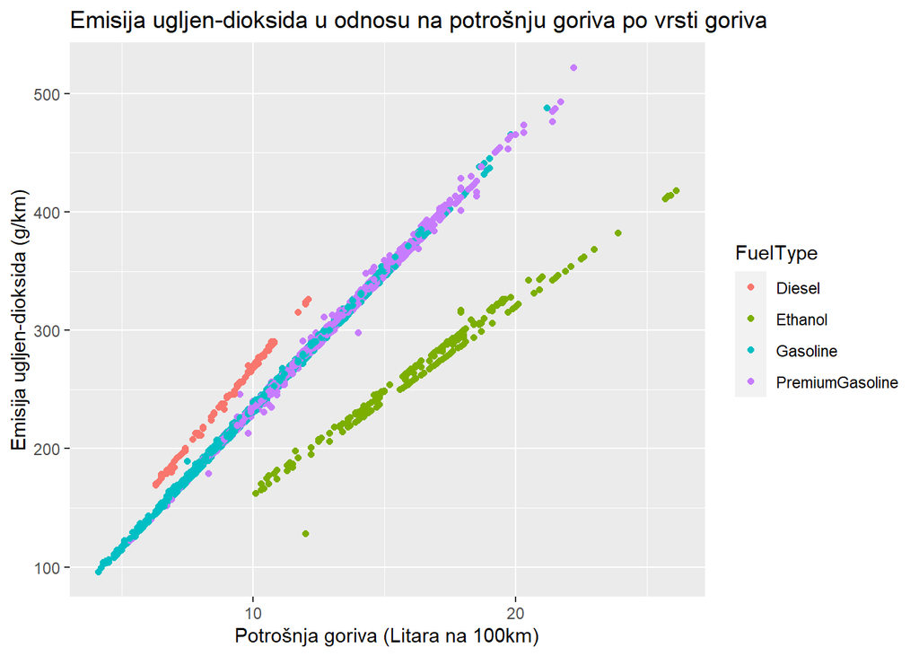

```r
ggplot(co2_emission, aes(x = FCComb, y = CO2Emission, color = FuelType)) +
  geom_point() +
  labs(title = "Emisija ugljen-dioksida u odnosu na potrošnju goriva po vrsti goriva", x = "Potrošnja goriva (Litara na 100km)", y = "Emisija ugljen-dioksida (g/km)")
```

Sa ovog grafa možemo zaključiti da najveći porast emisija CO2 imamo kod dizela, pošto ista potrošnja kod benzina i etanloa rezultira u manjem zagađenju (za potrošnju od 10L/km zagađujemo manje ako vozimo benzinca) i to tim redosledom tj. kod etanola imamo najmanje zagađenje u odnosu na potrošnju goriva.

Par zavisnih kolona koje mogu imati nekakvu povezanost su fuel consumption i vehicle class. U smislu da tip karoserije može uticati na potrošnju goriva (veće karoserije imaju veći otpor vazduha, manji je fokus na aerodinamičnosti vozila). Na osnovu ove pretpostavke ćemo izvući proseke kombinovane potrošnje i uporediti ih na različitim tipovima karoserija.

**Povezanost između potrošnje goriva i veličine motora kao i broja cilindara ćemo smatrati trivijalnom i nećemo je proveravati vizuelno**

```r
consumptionByClass = co2_emission %>%
  group_by(VehicleClass) %>%
  summarize(AvgConsumption = mean(FCComb)) %>%
  arrange(desc(AvgConsumption))

consumptionByClass_df <- as.data.frame(consumptionByClass)

colnames(consumptionByClass_df) <- c("Vehicle Class", "Average Fuel Consumption")

print(head(consumptionByClass_df, 15), right=F)
```

```
##    Vehicle Class            Average Fuel Consumption
## 1  VAN - PASSENGER          19.192424
## 2  VAN - CARGO              18.718182
## 3  PICKUP TRUCK - STANDARD  13.880855
## 4  SUV - STANDARD           13.650204
## 5  MINIVAN                  11.935000
## 6  TWO-SEATER               11.921304
## 7  PICKUP TRUCK - SMALL     11.717610
## 8  FULL-SIZE                11.633646
## 9  SPECIAL PURPOSE VEHICLE  10.763636
## 10 SUBCOMPACT               10.574422
## 11 STATION WAGON - MID-SIZE 10.232075
## 12 SUV - SMALL              10.231800
## 13 MINICOMPACT              10.168712
## 14 MID-SIZE                  9.606625
## 15 COMPACT                   9.343933
```

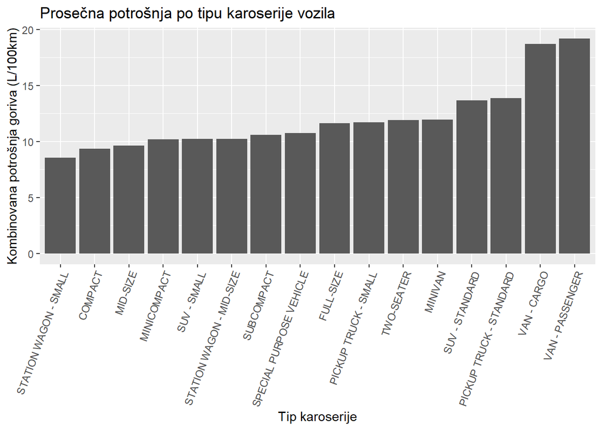

```r
ggplot(consumptionByClass, aes(x = reorder(VehicleClass, AvgConsumption), y = AvgConsumption)) +
  geom_bar(stat = "identity", position = "dodge") +
  xlab("Tip karoserije") +
  ylab("Kombinovana potrošnja goriva (L/100km)") +
  ggtitle("Prosečna potrošnja po tipu karoserije vozila") +
  theme(axis.text.x = element_text(angle = 70, hjust = 1))
```

Potrošnja goriva zaista zavisi dosta od tipa karoserije, veće karoserije imaju tendenciju da troše više goriva i na osnovu toga da više zagađuju. Ali opet imamo problem kao što smo imali gore kada smo upoređivali zagađenje i tip karoserije a to je da vozila manjih karoserija troše više od nekih vozila većih tako da ne možemo biti potpuno sigurni u ovaj zaključak ali je veza svakako tu.

Nakon toga možemo proveriti kako nam potrošnja goriva zavisi od marke vozila.

```r
consumptionByMake = co2_emission %>%
  group_by(Make) %>%
  summarize(AvgConsumption = mean(FCComb)) %>%
  arrange(desc(AvgConsumption))

consumptionByMake_df <- as.data.frame(consumptionByMake)

colnames(consumptionByMake_df) <- c("Vehicle Make", "Average Fuel Consumption")

print(head(consumptionByMake_df, 15), right=F)
```

```
##    Vehicle Make  Average Fuel Consumption
## 1  BUGATTI       22.20000
## 2  LAMBORGHINI   17.25610
## 3  SRT           16.90000
## 4  ROLLS-ROYCE   16.69000
## 5  BENTLEY       15.56739
## 6  ASTON MARTIN  14.58298
## 7  GMC           13.95579
## 8  MASERATI      13.61967
## 9  RAM           13.02268
## 10 LAND ROVER    12.77176
## 11 DODGE         12.51016
## 12 GENESIS       12.08800
## 13 FORD          12.00255
## 14 CHEVROLET     11.97274
## 15 MERCEDES-BENZ 11.91718
```

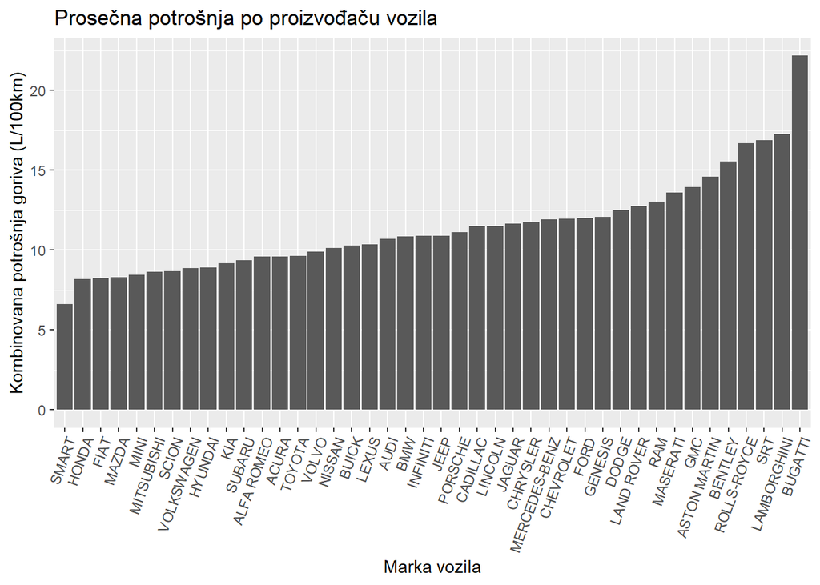

```r
ggplot(consumptionByMake, aes(x = reorder(Make, AvgConsumption), y = AvgConsumption)) +
  geom_bar(stat = "identity", position = "dodge") +
  xlab("Marka vozila") +
  ylab("Kombinovana potrošnja goriva (L/100km)") +
  ggtitle("Prosečna potrošnja po proizvođaču vozila") +
  theme(axis.text.x = element_text(angle = 70, hjust = 1))
```

Ovde primećujemo sličnu situaciju kao kada smo proverili pozvezanost emisije CO2 i marke, a to je da skupocene marke i marke iz SAD troše više goriva od evropskih ili marki iz Azije. Ovakva raspodela ima smisla, ali još jednu stvar koju možemo potvrditi na osnovu ove dve prethodne provere je da je potrošnja goriva usko povezana sa količinom izduvnih gasova.

Brisanje nepotrebnih vrednosti

```r
rm(colNamesDesc_df)
rm(custom_col_names)
rm(naCounts)
rm(na_counts_long)
rm(vehicleClassGroup)
rm(vehicleClassOrdered)
rm(emByMake_df)
rm(emByMake)
rm(vehicleClassCounts)
rm(emByVehicleClass)
rm(emByVehicleClass_df)
rm(engineClasses)
rm(emByEngineSize)
rm(emByEngineSize_df)
rm(data)
rm(cylindersCount)
rm(emByCylinders)
rm(emByCylinders_df)
rm(transmission_vehicles)
rm(tranType)
rm(emByGears)
rm(emByGears_df)
rm(emByTransmission)
rm(sorted_emByTransmission)
rm(fuelTypeCount)
rm(emByFuelType)
rm(emByFuelType_df)
rm(ethanolVehicles)
rm(consumptionByClass)
rm(consumptionByClass_df)
rm(consumptionByMake)
rm(consumptionByMake_df)
```

Nakon svega, da proverimo da li je raspodela podataka u numeričkim kolonama normalna

```r
library(gridExtra)
```

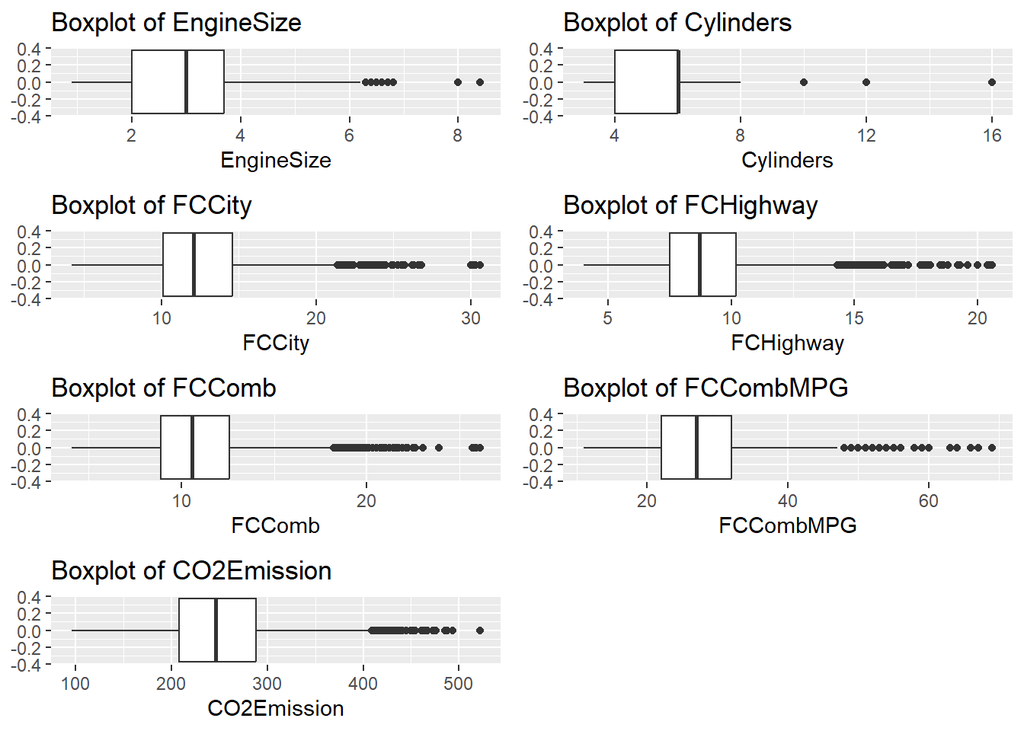

```r
numCols <- co2_emission[sapply(co2_emission, is.numeric)]

boxplot_list <- lapply(names(numCols), function(col_name) {
  ggplot(numCols, aes_string(x = col_name)) +
    geom_boxplot() +
    labs(title = paste("Boxplot of", col_name))
})
grid.arrange(grobs = boxplot_list, ncol = 2)
```

gridExtra biblioteku koristimo kako bi štampali sve plotove u jednom koraku, kako ne bi zauzimali mesto.

-Što se tiče veličine motora i broja cilindara, i ako imamo malo vrednosti nekih specifičnih veličina motora i broja cilindara, nećemo ih smatrati outlierima za sad pošto su te vrednosti realne i mogu se desiti, tj. nisu greška.

-Za ostale numeričke kolone deluje da imamo puno outliera, ali to su sve realne vrednosti, neki motori će zagađivati mnogo više, neki mnogo manje, ali možemo u kasnijem roku da probamo da skaliramo te vrednosti kako bi manje vukle model.

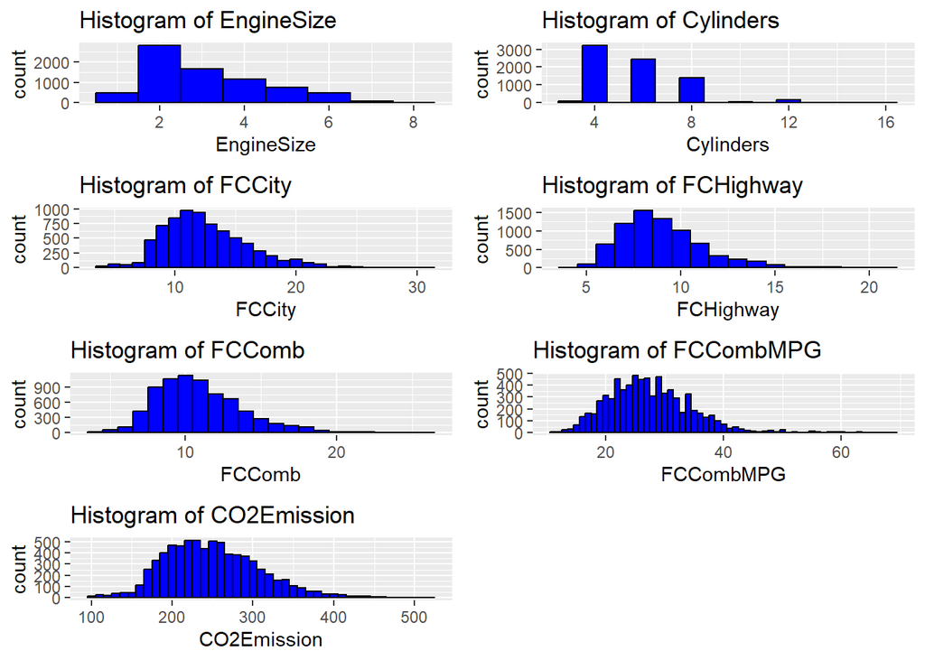

```r
#seq_along iterise i daje nam i
#u svim ce binwidth biti 1 sem u poslednjem gde ce biti 10 zbog ifelse

histogram_list <- lapply(seq_along(names(numCols)), function(i) {
  col_name <- names(numCols)[i]

  binwidth <- ifelse(i < length(numCols), 1, 10)

  ggplot(numCols, aes_string(x = col_name)) +
    geom_histogram(binwidth = binwidth, fill = "blue", color = "black") +
    labs(title = paste("Histogram of", col_name))
})

grid.arrange(grobs = histogram_list, ncol = 2)
```

Ovde možemo da primetimo da raspodela podataka u najvećem broju slučajeva ide ka desnoj strani plota (tj. da su right skewed) i da imamo dugačke repove koji označavaju ekstremne vrednosti, kolone nisu idealno normalno raspodeljene što može da loše utiče na naš model na dosta načina, pokušaćemo to da ispravimo kada budemo trenirali model.

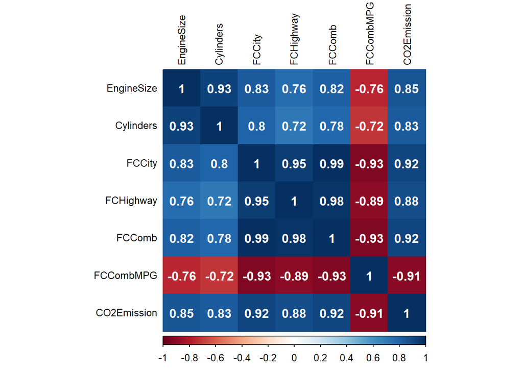

```r
corr_matrix <- cor(select_if(co2_emission, is.numeric))

corrplot(corr_matrix, is.corr = FALSE, method = 'color', col.lim = c(-1, 1), tl.col = 'black', tl.cex = 0.8,
         col = COL2('RdBu'), cl.pos = 'b', addCoef.col = 'white')
```

Sa korelacione matrice mozemo uočiti da su nam sve numeričke kolone u jakoj korelaciji sa CO2 emisijom. Pored toga, ove kolone su u najvećem broju slučajeva u korelaciji međusobno tako da je diskutabilno koliko će dodavanje većeg broja prediktora biti korisno u modelu, ali ćemo to svakako ispitati.

Za kategorijske promenljive ćemo proveravati usput kako utiču na modele i da li ih treba primenjivati

## Podela podataka na test i train u odnosu 70:30

```r
set.seed(123)

levelsFT = c("Gasoline", "PremiumGasoline", "Ethanol", "Diesel")

co2_emission$FuelType = factor(co2_emission$FuelType, levels = levelsFT)

index_train <- sample(seq_len(nrow(co2_emission)), 0.7 * nrow(co2_emission))

train <- co2_emission[index_train, ]

test<- co2_emission[-index_train, ]
```

## PRVI MODEL ~ FCCity

Za početak ćemo koristiti samo potrošnju po gradu, korelacija te kolone je dosta dobra (0.92)

```r
lmFCCity <- lm(CO2Emission ~ FCCity , data = train)

summary(lmFCCity)
```

```
##
## Call:
## lm(formula = CO2Emission ~ FCCity, data = train)
##
## Residuals:
##      Min       1Q   Median       3Q      Max
## -138.701   -7.092    1.644   11.604   73.747
##
## Coefficients:
##             Estimate Std. Error t value Pr(>|t|)
## (Intercept) 57.08206    1.18522   48.16   <2e-16 ***
## FCCity      15.41312    0.09091  169.54   <2e-16 ***
## ---
## Signif. codes:  0 '***' 0.001 '**' 0.01 '*' 0.05 '.' 0.1 ' ' 1
##
## Residual standard error: 23.04 on 5166 degrees of freedom
## Multiple R-squared:  0.8477, Adjusted R-squared:  0.8476
## F-statistic: 2.875e+04 on 1 and 5166 DF,  p-value: < 2.2e-16
```

Na osnovu statistika možemo zaključiti da je potrošnja po gradu značajna za predviđanje emisija CO2:

RSE nam je 23 jedinice mere, što nije loše pošto se naše vrednosti kreću od 100 do 500

Multilple R2 nam opisuje 0.85 varijanse u modelu što je takođe poprilično solidno, dok Adjusted R2 ne odstupa, što je i očekivano pošto koristimo samo jedan prediktor

F statistika je značajno velika a p vrednost dovoljno mala da možemo da odbacimo hipotezu da FCCity ne utiče na emisije CO2, tj. možemo reći da emisije CO2 zavise od potrošnje goriva u gradu.

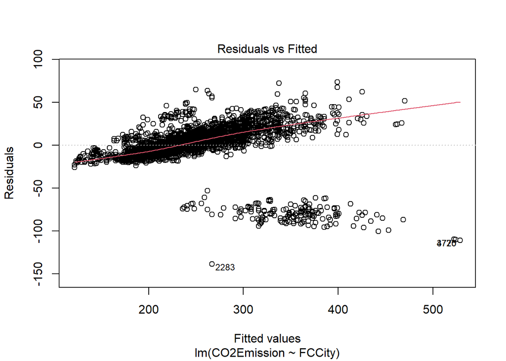

```r
plot(lmFCCity, which = 1)
```

**Residuals vs Fitted**

Na prvi pogled Residuals vs Fitted plot izgleda poprilično loše, za manje emisije ugljen dioksida model je poprilično precizan ali kako one rastu tako model počinje da ozbiljno da potcenjuje zagađenje, deluje kao da je modelu teško da predvidi zagađenje u slučaju da je potrošnja goriva velika, šta reći deluje da veza između potrošnje goriva i emisije CO2 i nije baš linearna. Pored toga, možemo videti i levkasti oblik raspodele, što ukazauje na heteroscedasticity.

Sve ovo ne znači da je potrošnja loš prediktor, već da nećemo moći da konzistentno pretpostavaljamo vrednost emisija CO2, a veoma je moguće da loša rapodela podataka utiče dosta na ovakav model, tj. onaj dugi rep kod FCCity koji smo mogli da primetimo kada smo plotovali raspodelu podataka za tu kolonu.

Dalje možemo ići u dva smera:

1. Pretpostavi da je moguće predvideti emisiju CO2 korišćenjem linearne regresije:

Tada možemo probati da popravimo ove metrike tako što ćemo transformisati neki od prediktora ili čak i izlaz nekom od prostih transformacija (sqrt, log), što može otežati čitljivost ovog modela.

Pokušati da otklonimo ove tačke sa visokom polugom korišćenjem neke od metoda za otkalnjanje outliera (IQR, Isolation Forest) što će uticati na sposobnost ovog modela da predviđa za ekstremne slučajeve.

Dodati nove prediktore u model.

2. Odustati od linearnog regresora i isprobati drugačije regresore koji se mogu bolje uklopiti sa ovako ne normalizovanim podacima.

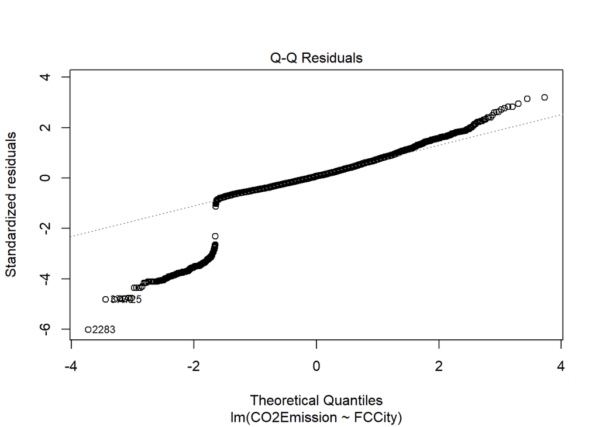

```r
plot(lmFCCity, which = 2)
```

**Normal Q-Q**

Ovde možemo proveriti da li je raspodela naših reziduala normalna i očigledno je da nije, šta reći imamo čak i “razdvajanje” tačaka, ali pošto naši podaci nisu bimodalni (imamo samo jednu “grbu” na histogramu) ovo je poprilično čudno, a to se možda može objasniti velikim brojem opservacija i time što imamo dosta ekstremnih vrednosti, ali svakako ovo je poprilično loše za model.

Možemo proveriti kako na primer vrednost 2283 biva predviđena od strane našeg modela i kakva je ona u realnosti radi boljeg razumevanja.

```r
library(kableExtra)
origRow <- train[2283, ]

prediction <- predict(lmFCCity, newdata = origRow)

origRow$predictions <- prediction

origRow_kable <- kable(origRow, format = "html") %>%
  kable_styling()

origRow_kable
```

| Make | Model | VehicleClass | EngineSize | Cylinders | Transmission | FuelType | FCCity | FCHighway | FCComb | FCCombMPG | CO2Emission | predictions |
| --- | --- | --- | --- | --- | --- | --- | --- | --- | --- | --- | --- | --- |
| MERCEDES-BENZ | GLA 250 4MATIC | SUV - SMALL | 2 | 4 | AS7 | Ethanol | 13.6 | 10 | 12 | 24 | 128 | 266.7005 |

Vidimo problem a pored toga i potencijalno rešenje istog, problem je to što u predikciji mašimo za skoro celu pravu vrednost emisija CO2, tj. da prepostavljamo previše pošto je potrošnja velika, ali ono što model ne uzima u obzir je to da ovo vozilo troši etanol koji zagađuje manje, a to nas dovodi do rešenja a to je da dodamo tip goriva u model, što ćemo i isprobati nakon analize ovog modela.

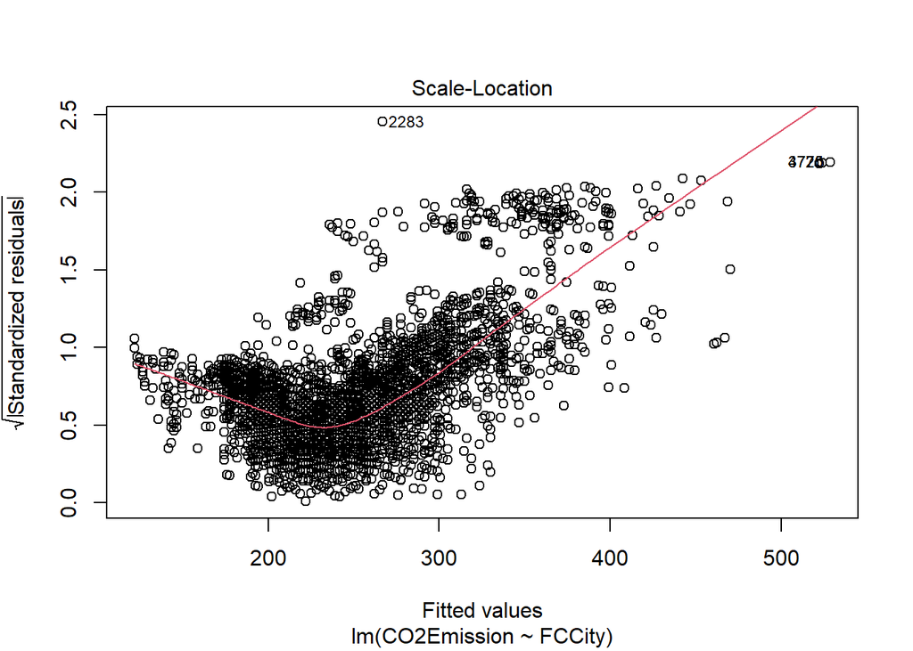

```r
plot(lmFCCity, which = 3)
```

**Scale location**

Ovaj plot nam omogućava da proverimo da li je varijansa naših reziduala jednaka, takođe imamo loše trendove i na ovom plotu, vidimo da se imamo skupljanje tačaka između 200 i 300 na X osi, i da crvena linija nije horizontalna, tako da imamo heteroscedasticity u modelu.

Formalan način da se ovo proveri (i ako je ovde već očigledno) je da se koristi Breusch Pagan test:

Nulta hipoteza je da su reziduali ravnomerno raspodeljeni (homoscedasticity postoji)

Alternativna hipoteza u slučaju da je p vrednost manja od 0.05 je da je prisutan heteroscedasticity

```r
library(lmtest)
bptest(lmFCCity)
```

```
##
##  studentized Breusch-Pagan test
##
## data:  lmFCCity
## BP = 1477.3, df = 1, p-value < 2.2e-16
```

P vrednost je apsurdno mala tako da nema govora o tome da su reziduali raspodeljeni ravnomerno.

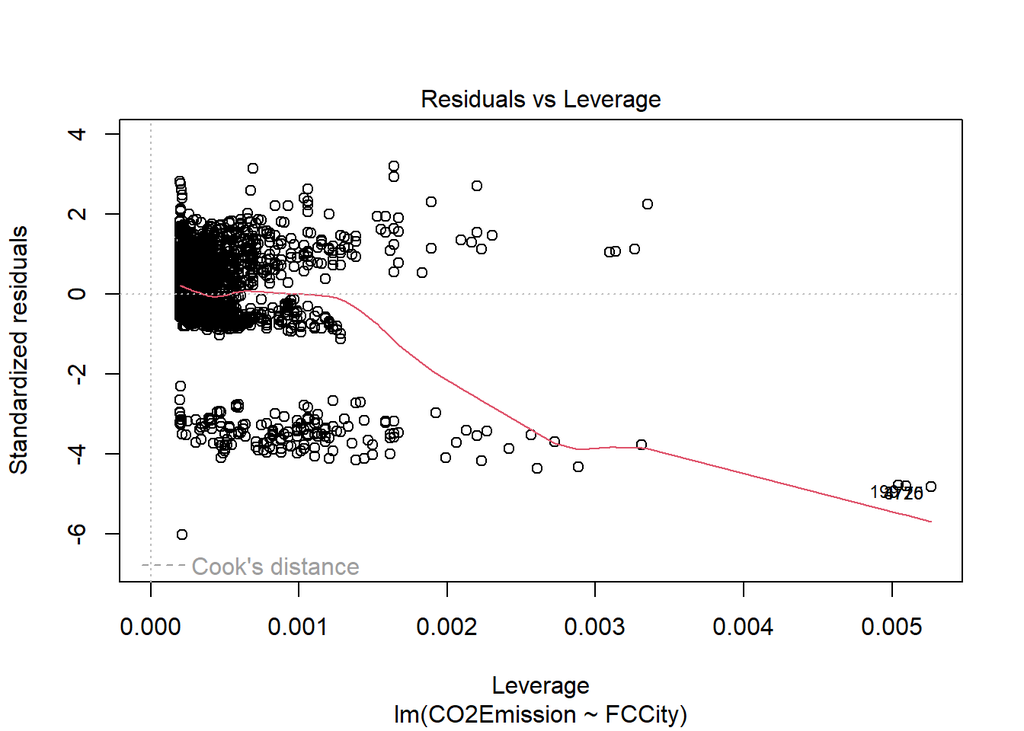

```r
plot(lmFCCity, which = 5)
```

**Residuals vs Leverage**

Ovde možemo videti koje tačke utiču dosta na naš model, tj. koje imaju visoku polugu

Na primer tačka 199, možemo da proverimo šta se dešava s njom

```r
origRow <- train[199, ]

prediction <- predict(lmFCCity, newdata = origRow)

origRow$predictions <- prediction

origRow_kable <- kable(origRow, format = "html") %>%
  kable_styling()

origRow_kable
```

| Make | Model | VehicleClass | EngineSize | Cylinders | Transmission | FuelType | FCCity | FCHighway | FCComb | FCCombMPG | CO2Emission | predictions |
| --- | --- | --- | --- | --- | --- | --- | --- | --- | --- | --- | --- | --- |
| CHEVROLET | EXPRESS 2500 PASSENGER FFV | VAN - PASSENGER | 6 | 8 | A6 | Ethanol | 30.3 | 20.5 | 25.9 | 11 | 414 | 524.0997 |

Evidentno je da ovo vozilo troši masivnu količinu goriva u gradu, opet se dešava da vozilo koristi etanol, do duše ovde je već zagađenje poprilično. Videćemo šta ćemo raditi dalje sa ovakvim primerima, možda je moguće da će se ovakve tačke bolje uklapati kako budemo dalje razvijali model.

## DRUGI MODEL ~ FCCity + FuelType

Sledeće što ćemo probati je da uvrstimo tip goriva u model kako ne bi imali problem sa vozilima koja koriste etanol,

Pre nego što dodamo ovaj faktor u model bilo bi ispravno enkodirati ga, ali to nećemo uraditi jer R sam po sebi obradjuje faktorske promenljive tj. enkodira ih, u suprotnom bi mi to morali da uradimo i pored toga bi morali da navedemo naziv svake od novih kolona u formuli.

```r
lmCT <- lm(CO2Emission ~ FCCity + FuelType , data = train)

summary(lmCT)
```

```
##
## Call:
## lm(formula = CO2Emission ~ FCCity + FuelType, data = train)
##
## Residuals:
##     Min      1Q  Median      3Q     Max
## -65.104  -4.943  -0.863   4.429  50.563
##
## Coefficients:
##                           Estimate Std. Error  t value Pr(>|t|)
## (Intercept)               22.16907    0.47977   46.208   <2e-16 ***
## FCCity                    18.65448    0.03946  472.713   <2e-16 ***
## FuelTypePremiumGasoline   -2.24361    0.25704   -8.729   <2e-16 ***
## FuelTypeEthanol         -109.89169    0.64370 -170.719   <2e-16 ***
## FuelTypeDiesel            28.87628    0.79748   36.210   <2e-16 ***
## ---
## Signif. codes:  0 '***' 0.001 '**' 0.01 '*' 0.05 '.' 0.1 ' ' 1
##
## Residual standard error: 8.522 on 5163 degrees of freedom
## Multiple R-squared:  0.9792, Adjusted R-squared:  0.9792
## F-statistic: 6.069e+04 on 4 and 5163 DF,  p-value: < 2.2e-16
```

To bi sve trebali da izvedemo ručno u slučaju da smo koristili one hot enkodiranje (ovaj fenomen se naziva dummy variable trap).

Svi tipovi goriva su očigledno značajni za model.

RSE nam je sa 23 spao na 8.5, što je višestruko poboljšanje.

Multilple R2 je skočio sa 0.85 na skoro 0.98 što je takođe odlično, a pored toga Adjusted R2 je identičan.

F statistika je značajno velika a p vrednost dovoljno mala da možemo da kažemo da su ove dve kolone (FCCity i FuelType) definitivno dobri prediktori emisija CO2.

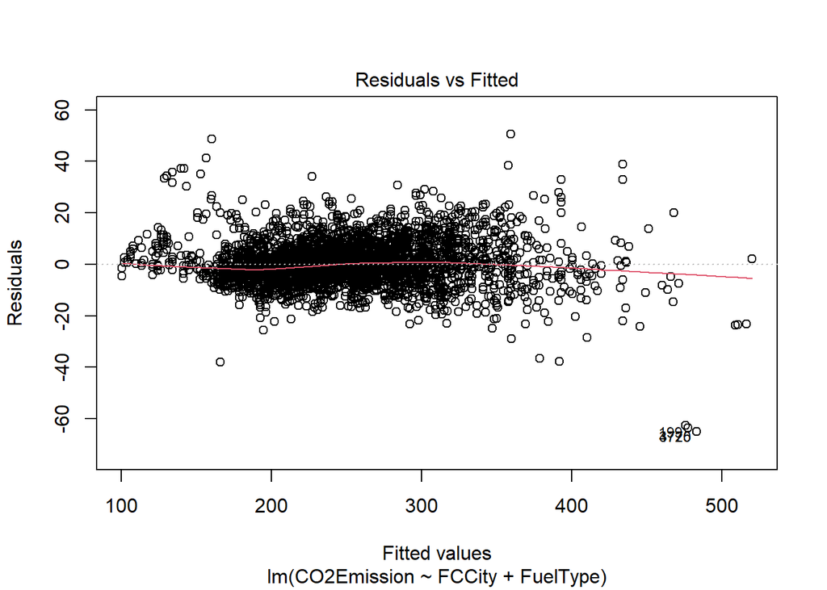

```r
plot(lmCT, which = 1)
```

**Residuals vs Fitted**

Vidimo očigledno poboljšanje i na ovom plotu, više nemamo odvojenu grupu reziduala gde model potcenjuje emisiju CO2, ali i dalje problem predstavljaju veće vrednosti emisija CO2, tačke se raspršuju kod njih što može značiti da i dalje imamo nekakav heteroscedasticity. Verovatno je da vrednosti sa visokom polugom utiču na ovo ili je to neko ponašanje koje naš model još ne može da objasni pošto i dalje modeliramo samo na osnovu dva prediktora.

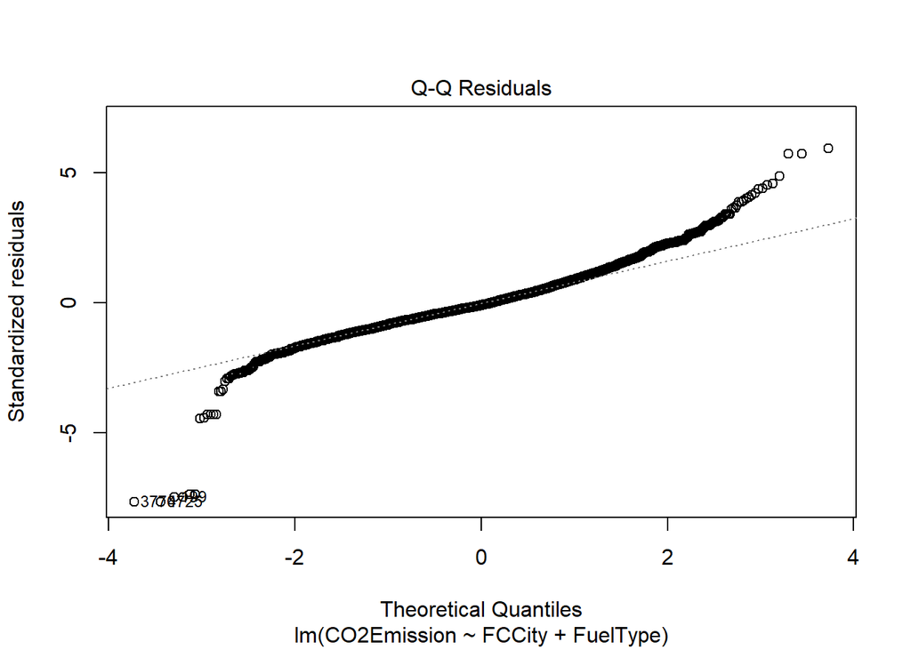

```r
plot(lmCT, which = 2)
```

**Normal q-q**